# AS! Case-mix trajectories

Ryan Stanley Falck

2026-05-13

# 1) Data Set-Up and Management

Load packages

```r
if (!require("pacman")) install.packages("pacman")
```

```r
pacman::p_load(readxl,psych,ggplot2,tableone,lavaan, semPlot, sem, semTools, tidyverse, haven, gbmt, dplyr, lcmm)
```

Set working directory

```r
setwd("~/Desktop/Manuscripts/Ongoing Projects/AS! Case-mix trajectories")
```

Load data

```r
falls_plus_HRU<-read_excel("AS_Econ_Falls_HRU_merge_Feb 22 2021.xlsx")
geris<-read_excel("AS Geri_July 30 2018.xlsx")
HRUs1 <- read_excel("AS! HRU Q1-3_June 13 2019.xlsx", sheet = "HRU Q1")
HRUs2 <- read_excel("AS! HRU Q1-3_June 13 2019.xlsx", sheet = "HRU Q2")
HRUs3 <- read_excel("AS! HRU Q1-3_June 13 2019.xlsx", sheet = "HRU Q3")
```

Data management of individual data frames. Preparing for merging

```r
falls_plus_HRU_2<-subset(falls_plus_HRU, assessmenperiod == 1)
falls_plus_HRU_2$Stroop3_2<-as.numeric(falls_plus_HRU_2$`Stroop 3`) - as.numeric(falls_plus_HRU_2$`Stroop 2`)
falls_plus_HRU_2$DSFB<-as.numeric(falls_plus_HRU_2$`Digit F`) - as.numeric(falls_plus_HRU_2$`Digit B`)
falls_plus_HRU_3<-falls_plus_HRU_2[c(1,3,4,7:10,34:36,39,40,41,45,49:51,52:54,65:71,72,76,79,82,83)]
falls_plus_HRU_3<-rename(falls_plus_HRU_3,c("ID"="id"))

geris_2<-subset(geris, ID != 330)
```

HRUQ1 Management

```r
#Create dataframe
HRUs1_2 <- HRUs1[c(1,2,7)]
HRUs1_3<-rename(HRUs1_2,c("Time"="Assessmen Period"))
HRUs1_4<-subset(HRUs1_3,Time!="Lagime")
HRUs1_4$Time<-as.numeric(HRUs1_4$Time)

#Delete duplicates
HRUs1_5<-distinct(HRUs1_4)

#Resolve remaining multiple values
HRUs1_6<-HRUs1_5[-c(909,3128,3129),] #Resolves double input for ID=197 Time=1. Removes both inputs for ID=369 Time=3 (inputting manually)

#Insert missing values
ID<-c(171,171,171,251,255,255,255,255,255,369,369)
Time<-c(2,11,12,13,7,8,9,10,11,5,3)
hruq1t<-c(NA,NA,NA,NA,NA,NA,NA,NA,NA,NA,563.3191)
missing<-data.frame(ID,Time,hruq1t)
HRUs1_final<-rbind(HRUs1_6, missing)
```

HRUQ2 Management

```r
#Create dataframe
HRUs2_2<-rename(HRUs2,c("Time"="Assessmen Period"))
HRUs2_3<-subset(HRUs2_2,Time!="Lagime")
HRUs2_3$Time<-as.numeric(HRUs2_3$Time)

#Delete duplicates
HRUs2_4<-distinct(HRUs2_3)

#No remaining multiple values

#Insert missing values
ID<-c(171,171,171,251,255,255,255,255,255,369)
Time<-c(2,11,12,13,7,8,9,10,11,5)
hruq2total<-c(NA,NA,NA,NA,NA,NA,NA,NA,NA,NA)
missing_2<-data.frame(ID,Time,hruq2total)
HRUs2_final<-rbind(HRUs2_4, missing_2)
```

HRUQ3 Management

```r
HRUs3_2<-rename(HRUs3,c("Time"="Assessmen Period"))
HRUs3_2$Time<-as.factor(HRUs3_2$Time)

#Delete duplicates
HRUs3_3<-distinct(HRUs3_2)

#Resolve remaining multiple values
HRUs3_4<-HRUs3_3[!(HRUs3_3$ID=="369" & HRUs3_3$Time=="3"),]#Removes both inputs for ID=369 Time=3 (inputting manually)

ID<-c(171,171,171,251,255,255,255,255,255,369,369)
Time<-c(2,11,12,13,7,8,9,10,11,5,3)
hruq3total<-c(NA,NA,NA,NA,NA,NA,NA,NA,NA,NA,314.7633)
missing_3<-data.frame(ID,Time,hruq3total)
HRUs3_final<-rbind(HRUs3_4, missing_3)
```

Merge HRU data

```r
HRUstotal_1<- merge(HRUs1_final,HRUs2_final)
HRUstotal_final<- merge(HRUstotal_1,HRUs3_final)
```

Create HRU Total Cost

```r
#HRU total cost across three categories
HRUstotal_final$HRU_totalcost<-HRUstotal_final$hruq1t + HRUstotal_final$hruq2total + HRUstotal_final$hruq3total

#Accounting for inflation
HRUstotal_final$HRU_totalcost_inflated<-HRUstotal_final$HRU_totalcost *1.1110

#Because the costs are large numbers, this will shrink the dependent variable and hopefully improve model fit
HRUstotal_final$HRU_totalcost_small <- HRUstotal_final$HRU_totalcost_inflated/1000

#As another alternative I normalized cost data in order to account for the issues of non-normality using a min-max normalization
HRUstotal_final$HRU_normalized <- (HRUstotal_final$HRU_totalcost_small - min(HRUstotal_final$HRU_totalcost_small, na.rm=TRUE)) / (max(HRUstotal_final$HRU_totalcost_small, na.rm = TRUE) - min(HRUstotal_final$HRU_totalcost_small, na.rm = TRUE))

#I also log-transformed cost data in order to account for the issues of non-normality using a min-max normalization
HRUstotal_final$HRU_log <- log(HRUstotal_final$HRU_totalcost_inflated + 1)
```

Create final data frame for all variables

```r
long.data<-merge(falls_plus_HRU_3, HRUstotal_final)
```

Final Data Management

```r
long.data2<-long.data[c(1:3,8,33,38:41)]
long.data2$Group<-as.factor(long.data2$Group)
```

Note: Two participants did not provide HRU data (ID= 330 and ID=450). All other participants were included in the model.

# 2) Fitting the primary model

```r
model1<-lcmm(HRU_totalcost_small~Time, random=~ Time, subject='ID', ng = 1 , link = 'linear', data = long.data2)
model2<-lcmm(HRU_totalcost_small~Time, random=~Time, subject='ID', ng = 1 , link = '3-equi-splines', data = long.data2)
model3<-lcmm(HRU_totalcost_small~Time, random=~Time, subject='ID', ng = 1 , link = '3-quant-splines', data = long.data2)
model4<-lcmm(HRU_totalcost_small~Time + I(Time^2), random=~ Time + I(Time^2), subject='ID', ng = 1 , link = 'linear', data = long.data2)
model5<-lcmm(HRU_totalcost_small~Time + I(Time^2), random=~Time + I(Time^2), subject='ID', ng = 1 , link = '3-equi-splines', data = long.data2)
model6<-lcmm(HRU_totalcost_small~Time + I(Time^2), random=~Time + I(Time^2), subject='ID', ng = 1 , link = '3-quant-splines', data = long.data2)
model7<-lcmm(HRU_totalcost_small~Time + I(Time^2) + I(Time^3), random=~ Time + I(Time^2) + I(Time^3), subject='ID', ng = 1 , link = 'linear', data = long.data2)
model8<-lcmm(HRU_totalcost_small~Time + I(Time^2) + I(Time^3), random=~Time + I(Time^2) + I(Time^3), subject='ID', ng = 1 , link = '3-equi-splines', data = long.data2)
model9<-lcmm(HRU_totalcost_small~Time + I(Time^2) + I(Time^3), random=~Time + I(Time^2) + I(Time^3), subject='ID', ng = 1 , link = '3-quant-splines', data = long.data2)

summarytable(model1, model2, model3, model4, model5, model6, model7, model8, model9, which = c("G", "loglik", "conv", "npm", "AIC", "BIC", "SABIC", "entropy","ICL", "%class"))
```

```
##        G     loglik conv npm       AIC       BIC     SABIC entropy      ICL1
## model1 1  -8665.680    1   6 17343.359 17366.386 17347.352       1 17366.386
## model2 1  -4992.355    1   9 10002.709 10037.249 10008.699       1 10037.249
## model3 1  -1165.166    1   9  2348.332  2382.871  2354.321       1  2382.871
## model4 1  -8626.885    1  10 17273.769 17312.146 17280.424       1 17312.146
## model5 1  -4980.610    1  13  9987.221 10037.111  9995.872       1 10037.111
## model6 1  -1150.680    1  13  2327.360  2377.250  2336.011       1  2377.250
## model7 1 -12789.194    2  15 25608.388 25665.954 25618.370       1 25665.954
## model8 1 -11957.565    2  18 23951.130 24020.209 23963.108       1 24020.209
## model9 1  -7320.979    2  18 14677.958 14747.037 14689.937       1 14747.037
##             ICL2 %class1
## model1 17366.386     100
## model2 10037.249     100
## model3  2382.871     100
## model4 17312.146     100
## model5 10037.111     100
## model6  2377.250     100
## model7 25665.954     100
## model8 24020.209     100
## model9 14747.037     100
```

We then compared the estimated functions by plot.

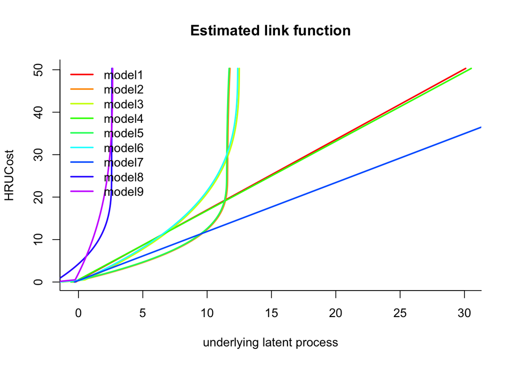

```r
col <- rainbow(10)
plot(model1, which="linkfunction",bty='l', ylab="HRUCost", col=col[1], lwd=2, xlab="underlying latent process")
plot(model2, which="linkfunction", add=TRUE, col=col[2], lwd=2)
plot(model3, which="linkfunction", add=TRUE, col=col[3], lwd=2)
plot(model4, which="linkfunction", add=TRUE, col=col[4], lwd=2)
plot(model5, which="linkfunction", add=TRUE, col=col[5], lwd=2)
plot(model6, which="linkfunction", add=TRUE, col=col[6], lwd=2)
plot(model7, which="linkfunction", add=TRUE, col=col[7], lwd=2)
plot(model8, which="linkfunction", add=TRUE, col=col[8], lwd=2)
plot(model9, which="linkfunction", add=TRUE, col=col[9], lwd=2)
legend(x="topleft", legend=c("model1", "model2","model3","model4","model5","model6","model7","model8","model9"), lty=1, col=col, bty="n", lwd=2)
```

First order models are described below. The best fitting models is model3d (4 classes).

```r
model3a<-lcmm(HRU_totalcost_small~Time, random=~Time, subject='ID', ng = 1 , link = '3-quant-splines', data = long.data2)
model3b<-lcmm(HRU_totalcost_small~Time, random=~Time, mixture =~ Time, subject='ID', ng = 2 , link = '3-quant-splines', data = long.data2, B=model3)
model3c<-lcmm(HRU_totalcost_small~Time, random=~Time, mixture =~ Time, subject='ID', ng = 3 , link = '3-quant-splines', data = long.data2, B=model3)
model3d<-lcmm(HRU_totalcost_small~Time, random=~Time, mixture =~ Time, subject='ID', ng = 4 , link = '3-quant-splines', data = long.data2, B=model3)
model3e<-lcmm(HRU_totalcost_small~Time, random=~Time, mixture =~ Time, subject='ID', ng = 5 , link = '3-quant-splines', data = long.data2, B=model3)
model3f<-lcmm(HRU_totalcost_small~Time, random=~Time, mixture =~ Time, subject='ID', ng = 6 , link = '3-quant-splines', data = long.data2, B=model3)

summarytable(model3a, model3b, model3c, model3d, model3e, model3f, which = c("G", "loglik", "conv", "npm", "AIC", "BIC", "SABIC", "entropy","ICL", "%class"))
```

```
##         G    loglik conv npm      AIC      BIC    SABIC   entropy     ICL1
## model3a 1 -1165.166    1   9 2348.332 2382.871 2354.321 1.0000000 2382.871
## model3b 2 -1154.387    2  12 2332.773 2378.826 2340.759 0.9228055 2397.179
## model3c 3 -1154.385    2  15 2338.770 2396.336 2348.753 0.4764691 2593.615
## model3d 4 -1134.473    2  18 2304.946 2374.025 2316.925 0.7875196 2475.059
## model3e 5 -1134.459    2  21 2310.919 2391.511 2324.894 0.5872627 2619.358
## model3f 6 -1129.362    2  24 2306.724 2398.829 2322.695 0.6685347 2602.539
##             ICL2     %class1  %class2   %class3    %class4  %class5 %class6
## model3a 2382.871 100.0000000
## model3b 2393.879   2.9154519 97.08455
## model3c 2588.697   3.2069971 96.79300  0.000000
## model3d 2474.652   0.8746356 71.42857  2.623907 25.0728863
## model3e 2628.907   0.8746356 29.44606 67.055394  2.6239067  0.00000
## model3f 2595.671   2.3323615 64.72303  2.332362  0.8746356 29.73761       0
```

Second order models are described below. Model6c (3 classes), model6d (4 classes), model6e (5 classes), and model6f (6 classes) are the best fitting models

```r
model6a<-lcmm(HRU_totalcost_small~Time + I(Time^2), random=~Time + I(Time^2), subject='ID', ng = 1 , link = '3-quant-splines', data = long.data2)
model6b<-lcmm(HRU_totalcost_small~Time + I(Time^2), random=~Time + I(Time^2), mixture =~ Time + I(Time^2), subject='ID', ng = 2 , link = '3-quant-splines', data = long.data2, B=model6)
model6c<-lcmm(HRU_totalcost_small~Time + I(Time^2), random=~Time + I(Time^2), mixture =~ Time + I(Time^2), subject='ID', ng = 3 , link = '3-quant-splines', data = long.data2, B=model6)
model6d<-lcmm(HRU_totalcost_small~Time + I(Time^2), random=~Time + I(Time^2), mixture =~ Time + I(Time^2), subject='ID', ng = 4 , link = '3-quant-splines', data = long.data2, B=model6)
model6e<-lcmm(HRU_totalcost_small~Time + I(Time^2), random=~Time + I(Time^2), mixture =~ Time + I(Time^2), subject='ID', ng = 5 , link = '3-quant-splines', data = long.data2, B=model6)
model6f<-lcmm(HRU_totalcost_small~Time + I(Time^2), random=~Time + I(Time^2), mixture =~ Time + I(Time^2), subject='ID', ng = 6 , link = '3-quant-splines', data = long.data2, B=model6)

summarytable(model6a, model6b, model6c, model6d, model6e, model6f, which = c("G", "loglik", "conv", "npm", "AIC", "BIC", "SABIC", "entropy","ICL", "%class"))
```

```
##         G    loglik conv npm      AIC      BIC    SABIC   entropy     ICL1
## model6a 1 -1150.680    1  13 2327.360 2377.250 2336.011 1.0000000 2377.250
## model6b 2 -1088.553    1  17 2211.107 2276.348 2222.420 0.9993027 2276.514
## model6c 3 -1062.679    2  21 2167.357 2247.950 2181.333 0.9967722 2249.166
## model6d 4 -1079.445    2  25 2208.890 2304.833 2225.527 0.7239712 2436.085
## model6e 5 -1058.754    2  29 2175.508 2286.802 2194.807 0.6715704 2468.107
## model6f 6 -1048.670    2  33 2163.341 2289.986 2185.302 0.8372402 2390.014
##             ICL2    %class1   %class2    %class3    %class4   %class5  %class6
## model6a 2377.250 100.000000
## model6b 2276.413   1.457726 98.542274
## model6c 2248.936   1.457726 97.667638  0.8746356
## model6d 2430.642   1.457726 70.845481 23.9067055  3.7900875
## model6e 2455.190   1.457726  1.457726 94.1690962  0.8746356 2.0408163
## model6f 2387.058   1.166181  1.457726 67.0553936 27.1137026 0.8746356 2.332362
```

The best fitting models are then compared here

```r
summarytable(model3d, model6c, model6d, model6e, model6f, which = c("G", "loglik", "conv", "npm", "AIC", "BIC", "SABIC", "entropy","ICL", "%class"))
```

```
##         G    loglik conv npm      AIC      BIC    SABIC   entropy     ICL1
## model6c 3 -1062.679    2  21 2167.357 2247.950 2181.333 0.9967722 2249.166
## model3d 4 -1134.473    2  18 2304.946 2374.025 2316.925 0.7875196 2475.059
## model6d 4 -1079.445    2  25 2208.890 2304.833 2225.527 0.7239712 2436.085
## model6e 5 -1058.754    2  29 2175.508 2286.802 2194.807 0.6715704 2468.107
## model6f 6 -1048.670    2  33 2163.341 2289.986 2185.302 0.8372402 2390.014
##             ICL2   %class1   %class2    %class3    %class4   %class5  %class6
## model6c 2248.936 1.4577259 97.667638  0.8746356
## model3d 2474.652 0.8746356 71.428571  2.6239067 25.0728863
## model6d 2430.642 1.4577259 70.845481 23.9067055  3.7900875
## model6e 2455.190 1.4577259  1.457726 94.1690962  0.8746356 2.0408163
## model6f 2387.058 1.1661808  1.457726 67.0553936 27.1137026 0.8746356 2.332362
```

Summary plots comparing models are here

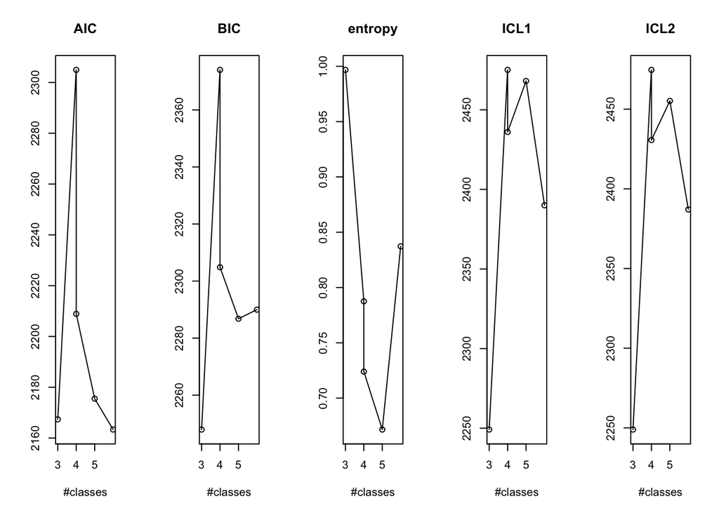

```r
summaryplot(model3d, model6c, model6d, model6e, model6f, which = c("AIC", "BIC", "entropy", "ICL"))
```

Based on these results, it seems that each model is somewhat comparable. Thus, we plotted each of the case-mix trajectories in order to determine which one appeared to best explain the data

Model 3d: 1st order with 4 classes

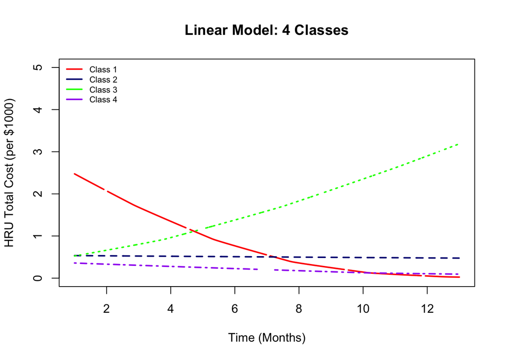

```r
OEP_data<-data.frame(Time= seq(1,13, length=1000))
OEP_pred <- predictY(model3d, OEP_data, var.time ="Time", draws = FALSE)
plot(OEP_pred, col=c("red","navy", "green", "purple"), lwd = 2, xlab="Time (Months)", ylab="HRU Total Cost (per $1000)", legend=NULL, main="Linear Model: 4 Classes",ylim=c(0,5))
legend(x="topleft",legend=c("Class 1","Class 2", "Class 3", "Class 4"), col=c("red","navy", "green",  "purple"), lty=1,lwd=2, ncol=1, bty="n", cex = 0.7)
```

Model 6C: 2nd order with 3 classes

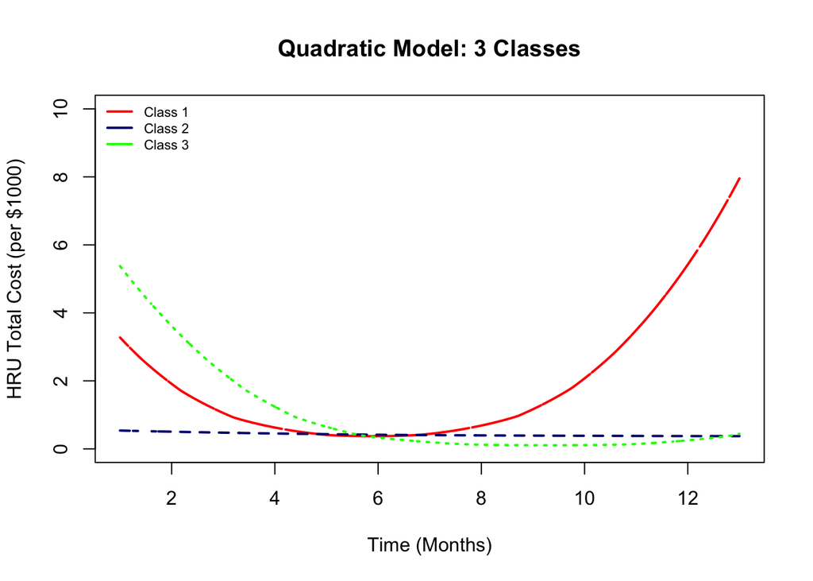

```r
OEP_data<-data.frame(Time= seq(1,13, length=1000))
OEP_pred <- predictY(model6c, OEP_data, var.time ="Time", draws = FALSE)
plot(OEP_pred, col=c("red","navy", "green"), lwd = 2, xlab="Time (Months)", ylab="HRU Total Cost (per $1000)", legend=NULL,  main="Quadratic Model: 3 Classes",ylim=c(0,10))
legend(x="topleft",legend=c("Class 1","Class 2", "Class 3"), col=c("red","navy", "green"), lty=1,lwd=2, ncol=1, bty="n", cex = 0.7)
```

Model 6D: 2nd order with 4 classes

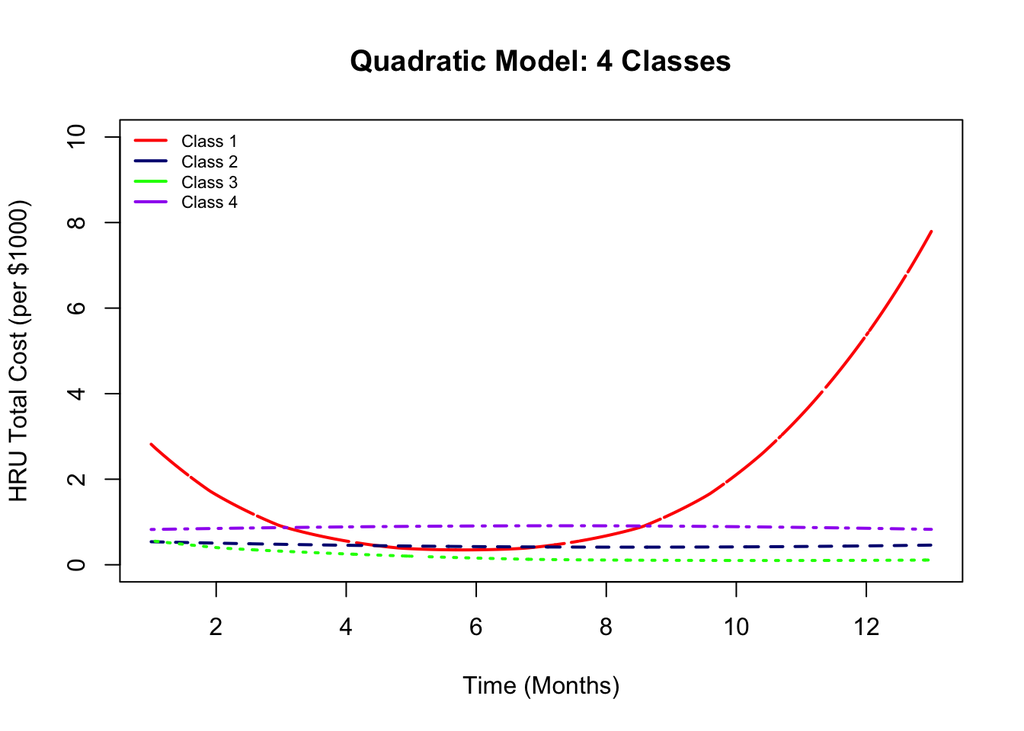

```r
OEP_data<-data.frame(Time= seq(1,13, length=1000))
OEP_pred <- predictY(model6d, OEP_data, var.time ="Time", draws = FALSE)
plot(OEP_pred, col=c("red","navy", "green", "purple"), lwd = 2, xlab="Time (Months)", ylab="HRU Total Cost (per $1000)",legend=NULL,main="Quadratic Model: 4 Classes",ylim=c(0,10))
legend(x="topleft",legend=c("Class 1","Class 2", "Class 3", "Class 4"), col=c("red","navy", "green", "purple"), lty=1,lwd=2, ncol=1, bty="n", cex = 0.7)
```

Model 6E: 2nd order with 5 classes

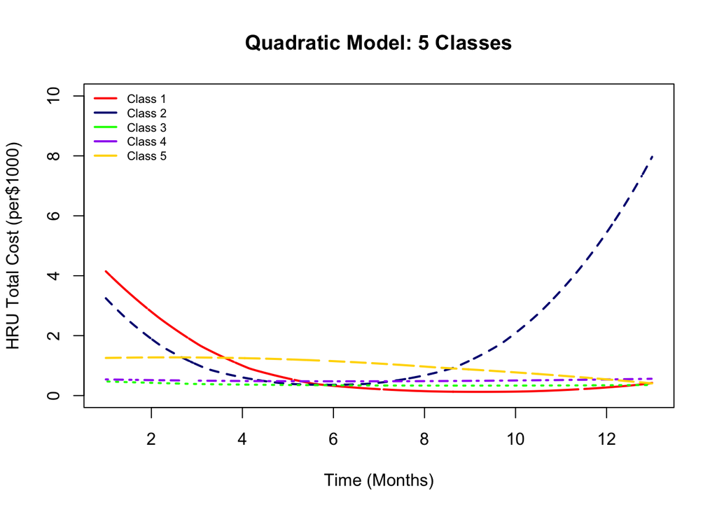

```r
OEP_data<-data.frame(Time= seq(1,13, length=1000))
OEP_pred <- predictY(model6e, OEP_data, var.time ="Time", draws = FALSE)
plot(OEP_pred, col=c("red","navy", "green", "purple", "gold"), lwd = 2, xlab="Time (Months)", ylab="HRU Total Cost (per$1000)",legend=NULL,  main="Quadratic Model: 5 Classes",ylim=c(0,10))
legend(x="topleft",legend=c("Class 1","Class 2", "Class 3", "Class 4", "Class 5"), col=c("red","navy", "green", "purple", "gold"), lty=1,lwd=2, ncol=1, bty="n", cex = 0.7)
```

Model 6F: 2nd order with 6 classes

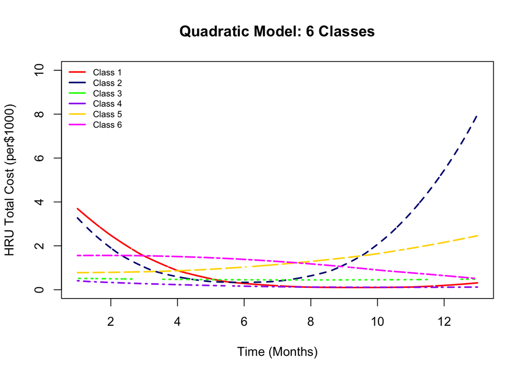

```r
OEP_data<-data.frame(Time= seq(1,13, length=1000))
OEP_pred <- predictY(model6f, OEP_data, var.time ="Time", draws = FALSE)
plot(OEP_pred, col=c("red","navy", "green", "purple", "gold", "magenta"), lwd = 2, xlab="Time (Months)", ylab="HRU Total Cost (per$1000)",legend=NULL,  main="Quadratic Model: 6 Classes",ylim=c(0,10))
legend(x="topleft",legend=c("Class 1","Class 2", "Class 3", "Class 4", "Class 5", "Class 6"), col=c("red","navy", "green", "purple", "gold", "magenta"), lty=1,lwd=2, ncol=1, bty="n", cex = 0.7)
```

## 2.1) Final model

Based on these data, the final model was a linear 4 class model using 3-quant splines.

```r
summary(model3d)
```

```
## General latent class mixed model
##      fitted by maximum likelihood method
##
## lcmm(fixed = HRU_totalcost_small ~ Time, mixture = ~Time, random = ~Time,
##     subject = "ID", ng = 4, link = "3-quant-splines", data = long.data2)
##
## Statistical Model:
##      Dataset: long.data2
##      Number of subjects: 343
##      Number of observations: 4445
##      Number of observations deleted: 14
##      Number of latent classes: 4
##      Number of parameters: 18
##      Link function: Quadratic I-splines with nodes
## 0 0.1251695 50.315
##
## Iteration process:
##      Maximum number of iteration reached without convergence
##      Number of iterations:  100
##      Convergence criteria: parameters= 8.2e-06
##                          : likelihood= 0.00048
##                          : second derivatives= 1
##
## Goodness-of-fit statistics:
##      maximum log-likelihood: -1134.47
##      AIC: 2304.95
##      BIC: 2374.03
##
##
## Maximum Likelihood Estimates:
##
## Fixed effects in the class-membership model:
## (the class of reference is the last class)
##
##                      coef Se Wald p-value
## intercept class1 -3.24276
## intercept class2  0.87003
## intercept class3 -2.43013
##
## Fixed effects in the longitudinal model:
```

[output cut: 12 more lines]

```
## Variance-covariance matrix of the random-effects:
##           intercept    Time
## intercept   0.08933
## Time       -0.00365 0.00015
##
## Residual standard error (not estimated) = 1
##
## Parameters of the link function:
##
##                coef Se Wald p-value
## I-splines1 -3.36655
## I-splines2  1.18471
## I-splines3  3.53339
## I-splines4 -0.00031
## I-splines5  0.22253
```

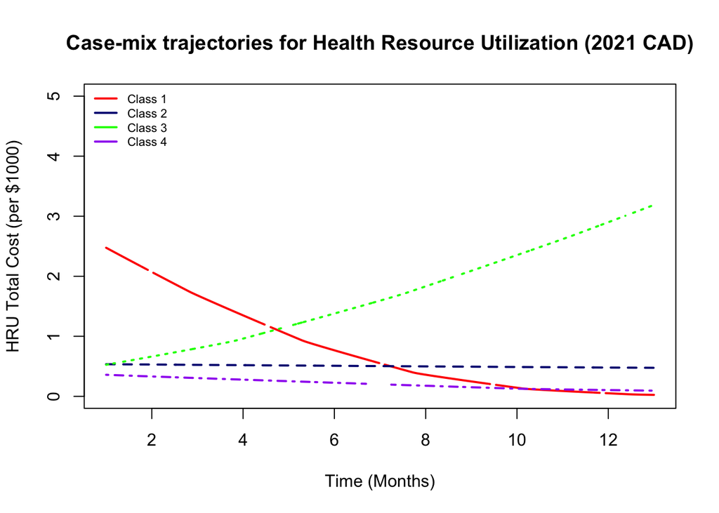

```r
OEP_data<-data.frame(Time= seq(1,13, length=1000))
OEP_pred <- predictY(model3d, OEP_data, var.time ="Time", draws = FALSE)
plot(OEP_pred, col=c("red","navy", "green", "purple"), lwd = 2, xlab="Time (Months)", ylab="HRU Total Cost (per $1000)", legend=NULL, main="Case-mix trajectories for Health Resource Utilization (2021 CAD)",ylim=c(0,5))
legend(x="topleft",legend=c("Class 1","Class 2", "Class 3", "Class 4"), col=c("red","navy", "green",  "purple"), lty=1,lwd=2, ncol=1, bty="n", cex = 0.7)
```

Plot in ggplot2

```r
OEP_pred <- predictY(model3d, OEP_data, var.time ="Time", draws = FALSE)
Time<-OEP_pred$times
Classes<-as.data.frame(OEP_pred$pred)
OEP_data_frame<-cbind(Time, Classes)

Class1_frame<-OEP_data_frame[c(1,2)]
Class2_frame<-OEP_data_frame[c(1,3)]
Class3_frame<-OEP_data_frame[c(1,4)]
Class4_frame<-OEP_data_frame[c(1,5)]
Class1_frame$Class<- "Class 1"
Class2_frame$Class<- "Class 2"
Class3_frame$Class<- "Class 3"
Class4_frame$Class<- "Class 4"
Class1_frame <- rename(Class1_frame, "Predicted" = "Ypred_class1")
Class2_frame <- rename(Class2_frame, "Predicted" = "Ypred_class2")
Class3_frame <- rename(Class3_frame, "Predicted" = "Ypred_class3")
Class4_frame <- rename(Class4_frame, "Predicted" = "Ypred_class4")

graph_data<-rbind(Class1_frame, Class2_frame, Class3_frame, Class4_frame)

figure1<-ggplot(graph_data, aes(x=Time, y=Predicted, group=Class)) + geom_smooth(aes(colour=Class)) + theme_classic() + xlab("Time (Months)") + ylab("HRU Total Cost (per $1000 CAD") + ylim(0,5)

ggsave("Figure 1 - case trajectories.tiff",figure1, width = 4, height = 4, dpi = 300)
```

Predicted posterior probabilities

```r
postprob(model3d)
```

```
##
## Posterior classification:
##   class1 class2 class3 class4
## N   3.00 245.00   9.00  86.00
## %   0.87  71.43   2.62  25.07
##
## Posterior classification table:
##      --> mean of posterior probabilities in each class
##         prob1  prob2  prob3  prob4
## class1 0.9501 0.0396 0.0000 0.0103
## class2 0.0018 0.8903 0.0013 0.1066
## class3 0.0000 0.0811 0.9189 0.0000
## class4 0.0060 0.1629 0.0000 0.8311
##
## Posterior probabilities above a threshold (%):
##          class1 class2 class3 class4
## prob>0.7 100.00  88.57  88.89  73.26
## prob>0.8 100.00  79.59  88.89  63.95
## prob>0.9  66.67  64.90  77.78  51.16
##
```

### 2.2) Describe classes

Create data frame with classes

```r
model3d.frame<-model3d$pprob

baseline.data<-merge(model3d.frame, falls_plus_HRU_3, by="ID")

baseline.data.2 <- rename(baseline.data, "Falls_number" = "Total Falls", "Final_Weight" = "Final Weight", "Final_Height"="Final Height", "WHR"="Waist to Hip Ratio","FCI"="FCI Total",
                          "IADL"="Total IADL", "TrailsBA"="Trail Difference","TUG"="Mean TUG", "GaitSpeed"="Gait Speed", "SPPB"="NIA Total Score")

baseline.data.2$Gender[baseline.data.2$Gender==1]<-"Female"
baseline.data.2$Gender[baseline.data.2$Gender==2]<-"Male"

baseline.data.2$BMI<-baseline.data.2$Final_Weight/((baseline.data.2$Final_Height/100)^2)
```

Describe participants

```r
baseline.vars<-dput(names(baseline.data.2[c(8,13,7,17,16,38,20,21,23,12,33,34,35,24,25,36,37)]))
```

```
## c("Group", "Age", "Gender", "Education", "WHR", "BMI", "GDS",
## "FCI", "IADL", "Falls_number", "TUG", "GaitSpeed", "SPPB", "MMSE",
## "MoCA", "Stroop3_2", "DSFB")
```

```r
baseline.data.2$Group<-as.factor(baseline.data.2$Group)

Table1_full<-CreateTableOne(vars=baseline.vars, data=baseline.data.2)
print(Table1_full,contDigits=2,missing=TRUE,quote=TRUE)
```

```
##                                                      ""
##  ""                                                   "Overall"       "Missing"
##   "n"                                                 "  343"         "    "
##   "Group = 1 (%)"                                     "  172 (50.1) " " 0.0"
##   "Age (mean (SD))"                                   "81.58 (6.09)"  " 0.0"
##   "Gender = Male (%)"                                 "  115 (33.5) " " 0.0"
##   "Education (%)"                                     "  "            "20.1"
##   "   Grades 9-13, without certificate or diploma"    "   22 ( 8.0) " "    "
##   "   High school certificate or diploma"             "   47 (17.2) " "    "
##   "   Less than grade 9"                              "    8 ( 2.9) " "    "
##   "   Some university without certificate or diploma" "   26 ( 9.5) " "    "
##   "   Trades or professional certificate or diploma"  "   41 (15.0) " "    "
##   "   University certificate or diploma"              "   13 ( 4.7) " "    "
##   "   University degree"                              "  117 (42.7) " "    "
##   "WHR (mean (SD))"                                   " 0.90 (0.10)"  "14.9"
##   "BMI (mean (SD))"                                   "27.22 (6.41)"  " 0.6"
##   "GDS (mean (SD))"                                   " 2.87 (2.52)"  " 0.0"
##   "FCI (mean (SD))"                                   " 3.78 (1.99)"  " 0.6"
##   "IADL (mean (SD))"                                  " 7.30 (1.17)"  " 0.3"
##   "Falls_number (mean (SD))"                          " 1.75 (3.03)"  " 0.0"
##   "TUG (mean (SD))"                                   "16.61 (6.71)"  " 0.3"
##   "GaitSpeed (mean (SD))"                             " 0.77 (0.34)"  " 0.0"
##   "SPPB (mean (SD))"                                  " 7.87 (2.25)"  " 0.0"
##   "MMSE (mean (SD))"                                  "27.76 (1.63)"  " 0.0"
##   "MoCA (mean (SD))"                                  "23.15 (3.36)"  " 0.0"
##   "Stroop3_2 (mean (SD))"                             "77.96 (41.70)" " 1.5"
##   "DSFB (mean (SD))"                                  " 3.58 (1.91)"  " 2.0"
```

```r
Table1_stratified<-CreateTableOne(vars=baseline.vars, strata="class", data=baseline.data.2)
print(Table1_stratified,contDigits=2,missing=TRUE,quote=TRUE)
```

```
##                                                      "Stratified by class"
##  ""                                                   "1"
##   "n"                                                 "    3"
##   "Group = 1 (%)"                                     "    2 ( 66.7) "
##   "Age (mean (SD))"                                   "79.67 (6.11)"
##   "Gender = Male (%)"                                 "    3 (100.0) "
##   "Education (%)"                                     "    "
##   "   Grades 9-13, without certificate or diploma"    "    0 (  0.0) "
##   "   High school certificate or diploma"             "    0 (  0.0) "
##   "   Less than grade 9"                              "    0 (  0.0) "
##   "   Some university without certificate or diploma" "    0 (  0.0) "
##   "   Trades or professional certificate or diploma"  "    0 (  0.0) "
##   "   University certificate or diploma"              "    0 (  0.0) "
##   "   University degree"                              "    2 (100.0) "
##   "WHR (mean (SD))"                                   " 0.98 (0.11)"
##   "BMI (mean (SD))"                                   "29.51 (3.18)"
##   "GDS (mean (SD))"                                   " 0.67 (0.58)"
##   "FCI (mean (SD))"                                   " 3.33 (1.53)"
##   "IADL (mean (SD))"                                  " 6.33 (1.53)"
##   "Falls_number (mean (SD))"                          " 0.33 (0.58)"
##   "TUG (mean (SD))"                                   "20.22 (4.96)"
##   "GaitSpeed (mean (SD))"                             " 0.47 (0.06)"
##   "SPPB (mean (SD))"                                  " 5.67 (2.52)"
##   "MMSE (mean (SD))"                                  "26.00 (1.00)"
##   "MoCA (mean (SD))"                                  "23.00 (3.46)"
##   "Stroop3_2 (mean (SD))"                             "94.56 (54.65)"
##   "DSFB (mean (SD))"                                  " 4.00 (2.00)"
##                                                      "Stratified by class"
##  ""                                                   "2"
##   "n"                                                 "  245"
##   "Group = 1 (%)"                                     "  122 (49.8) "
##   "Age (mean (SD))"                                   "81.32 (6.15)"
##   "Gender = Male (%)"                                 "   82 (33.5) "
##   "Education (%)"                                     "  "
##   "   Grades 9-13, without certificate or diploma"    "   19 (10.0) "
##   "   High school certificate or diploma"             "   29 (15.3) "
##   "   Less than grade 9"                              "    7 ( 3.7) "
##   "   Some university without certificate or diploma" "   19 (10.0) "
##   "   Trades or professional certificate or diploma"  "   31 (16.3) "
##   "   University certificate or diploma"              "    9 ( 4.7) "
```

[output cut: 80 more lines]

```
##   "   University certificate or diploma"              ""     "    "
##   "   University degree"                              ""     "    "
##   "WHR (mean (SD))"                                   ""     "14.9"
##   "BMI (mean (SD))"                                   ""     " 0.6"
##   "GDS (mean (SD))"                                   ""     " 0.0"
##   "FCI (mean (SD))"                                   ""     " 0.6"
##   "IADL (mean (SD))"                                  ""     " 0.3"
##   "Falls_number (mean (SD))"                          ""     " 0.0"
##   "TUG (mean (SD))"                                   ""     " 0.3"
##   "GaitSpeed (mean (SD))"                             ""     " 0.0"
##   "SPPB (mean (SD))"                                  ""     " 0.0"
##   "MMSE (mean (SD))"                                  ""     " 0.0"
##   "MoCA (mean (SD))"                                  ""     " 0.0"
##   "Stroop3_2 (mean (SD))"                             ""     " 1.5"
##   "DSFB (mean (SD))"                                  ""     " 2.0"
```

# 3) Moderation analysis

Moderation data set-up for cognitive and physical function

```r
long.data3<-long.data[c(1,19,20,30,33,38)]
long.data3$HRU_totalcost_small <- long.data3$HRU_totalcost_inflated/1000

#Binary variable for MCI (1=MCI)
long.data3$MCI<-NA
long.data3$MCI[long.data3$MoCA<26] <- 1
long.data3$MCI[long.data3$MoCA>=26] <- 0

#Binary variable for SPPB (1=Physical frailty)
long.data3$Frailty<-NA
long.data3$Frailty[long.data3$`NIA Total Score`<9] <- 1
long.data3$Frailty[long.data3$`NIA Total Score`>=9] <- 0

long.data4<-long.data3[c(1,5:9)]
```

## 3.1) Moderation by group

Model development

```r
long.data2$Group.1<-NA
long.data2$Group.1[long.data2$Group==0]<-"UC"
long.data2$Group.1[long.data2$Group==1]<-"OEP"


#Base model
group.model.base<-lcmm(HRU_totalcost_small~Time*Group.1, random=~Time, subject='ID', ng = 1, link = '3-quant-splines', data = long.data2)

#Full model
group.model.moderation<-lcmm(HRU_totalcost_small~Time*Group.1, random=~Time, subject='ID', mixture =~ Time*Group.1, ng = 4, link = '3-quant-splines', data = long.data2, B=group.model.base)
```

Base model summary

```r
summary(group.model.base)
```

```
## General latent class mixed model
##      fitted by maximum likelihood method
##
## lcmm(fixed = HRU_totalcost_small ~ Time * Group.1, random = ~Time,
##     subject = "ID", ng = 1, link = "3-quant-splines", data = long.data2)
##
## Statistical Model:
##      Dataset: long.data2
##      Number of subjects: 343
##      Number of observations: 4445
##      Number of observations deleted: 14
##      Number of latent classes: 1
##      Number of parameters: 11
##      Link function: Quadratic I-splines with nodes
## 0 0.1251695 50.315
##
## Iteration process:
##      Convergence criteria satisfied
##      Number of iterations:  39
##      Convergence criteria: parameters= 4.4e-08
##                          : likelihood= 8.7e-06
##                          : second derivatives= 1e-09
##
## Goodness-of-fit statistics:
##      maximum log-likelihood: -1164.74
##      AIC: 2351.48
##      BIC: 2393.7
##
##
## Maximum Likelihood Estimates:
##
## Fixed effects in the longitudinal model:
##
##                               coef      Se    Wald p-value
## intercept (not estimated)        0
## Time                      -0.02036 0.00661  -3.081 0.00206
## Group.1UC                  0.05659 0.07366   0.768 0.44230
## Time:Group.1UC            -0.00169 0.00942  -0.180 0.85749
##
##
## Variance-covariance matrix of the random-effects:
##           intercept    Time
## intercept   0.11222
## Time       -0.00216 0.00189
##
## Residual standard error (not estimated) = 1
##
## Parameters of the link function:
##
##                coef      Se    Wald p-value
## I-splines1 -1.21514 0.05499 -22.098 0.00000
## I-splines2  1.18787 0.01093 108.664 0.00000
## I-splines3  3.50483 0.02649 132.299 0.00000
## I-splines4  0.00002 0.03714   0.000 0.99960
## I-splines5  0.21826 0.09812   2.224 0.02612
```

Full moderation model summary

```r
summary(group.model.moderation)
```

```
## General latent class mixed model
##      fitted by maximum likelihood method
##
## lcmm(fixed = HRU_totalcost_small ~ Time * Group.1, mixture = ~Time *
##     Group.1, random = ~Time, subject = "ID", ng = 4, link = "3-quant-splines",
##     data = long.data2)
##
## Statistical Model:
##      Dataset: long.data2
##      Number of subjects: 343
##      Number of observations: 4445
##      Number of observations deleted: 14
##      Number of latent classes: 4
##      Number of parameters: 26
##      Link function: Quadratic I-splines with nodes
## 0 0.1251695 50.315
##
## Iteration process:
##      Convergence criteria satisfied
##      Number of iterations:  77
##      Convergence criteria: parameters= 5.6e-07
##                          : likelihood= 8.3e-06
##                          : second derivatives= 5e-07
##
## Goodness-of-fit statistics:
##      maximum log-likelihood: -1129.05
##      AIC: 2310.09
##      BIC: 2409.87
##
##
## Maximum Likelihood Estimates:
##
## Fixed effects in the class-membership model:
## (the class of reference is the last class)
##
##                      coef      Se    Wald p-value
## intercept class1  0.84267 0.63277   1.332 0.18296
## intercept class2  3.79637 0.51468   7.376 0.00000
## intercept class3  3.02070 0.54708   5.521 0.00000
##
```

[output cut: 21 more lines]

```
## Variance-covariance matrix of the random-effects:
##           intercept Time
## intercept   0.03231
## Time       -0.00039    0
##
## Residual standard error (not estimated) = 1
##
## Parameters of the link function:
##
##                coef      Se    Wald p-value
## I-splines1 -3.17184 0.32704  -9.699 0.00000
## I-splines2  1.17773 0.01139 103.362 0.00000
## I-splines3  3.54031 0.02649 133.644 0.00000
## I-splines4 -0.00118 0.02163  -0.054 0.95661
## I-splines5  0.22220 0.09972   2.228 0.02586
```

Graph

```r
OEP_mod_data<-data.frame(Time= seq(1,13, length=1000), Group.1=rep(c("OEP","UC")))
OEP_mod_pred <- predictY(group.model.moderation, OEP_mod_data, var.time ="Time", draws = FALSE)

Time<-OEP_mod_pred$times
Group <- rep(c('OEP', 'UC'), length.out = 1000)
Classes<-as.data.frame(OEP_mod_pred$pred)
OEP_mod_data_frame<-cbind(Time, Group, Classes)

Class1_frame<-OEP_mod_data_frame[c(1,2,3)]
Class2_frame<-OEP_mod_data_frame[c(1,2,4)]
Class3_frame<-OEP_mod_data_frame[c(1,2,5)]
Class4_frame<-OEP_mod_data_frame[c(1,2,6)]
Class1_frame$Class<- "Class 1"
Class2_frame$Class<- "Class 2"
Class3_frame$Class<- "Class 3"
Class4_frame$Class<- "Class 4"
Class1_frame <- rename(Class1_frame, "Predicted" = "Ypred_class1")
Class2_frame <- rename(Class2_frame, "Predicted" = "Ypred_class2")
Class3_frame <- rename(Class3_frame, "Predicted" = "Ypred_class3")
Class4_frame <- rename(Class4_frame, "Predicted" = "Ypred_class4")

graph_data<-rbind(Class1_frame, Class2_frame, Class3_frame, Class4_frame)

figure2A<-ggplot(graph_data, aes(x=Time, y=Predicted, color=Class, linetype=Group)) + geom_smooth(aes(colour=Class, linetype=Group)) + theme_classic() + xlab("Time (Months)") + ylab("HRU Total Cost (per $1000 CAD") + ylim(0,5)

ggsave("Figure 2A - case trajectories.tiff",figure2A, width = 4, height = 4, dpi = 300)
```

## 3.2) Moderation by age

Model development

```r
#Summarize Age variable
summary(long.data2$Age) #25% Quartile = 77; 75% Quartile = 86; Median = 82
```

```
##    Min. 1st Qu.  Median    Mean 3rd Qu.    Max.
##   70.00   77.00   82.00   81.58   86.00   97.00
```

```r
#Create binary age variable (i.e., > median age)
long.data2$Age_binary<-NA
long.data2$Age_binary[long.data2$Age<=82] <- "High"
long.data2$Age_binary[long.data2$Age>82]<-"Low"

#Base model
age.model.base<-lcmm(HRU_totalcost_small~Time*Age_binary, random=~Time, subject='ID', ng = 1, link = '3-quant-splines', data = long.data2)

#Full model
age.model.moderation<-lcmm(HRU_totalcost_small~Time*Age_binary, random=~Time, subject='ID', mixture =~ Time*Age_binary, ng = 4, link = '3-quant-splines', data = long.data2, B=age.model.base)
```

Base model summary

```r
summary(age.model.base)
```

```
## General latent class mixed model
##      fitted by maximum likelihood method
##
## lcmm(fixed = HRU_totalcost_small ~ Time * Age_binary, random = ~Time,
##     subject = "ID", ng = 1, link = "3-quant-splines", data = long.data2)
##
## Statistical Model:
##      Dataset: long.data2
##      Number of subjects: 343
##      Number of observations: 4445
##      Number of observations deleted: 14
##      Number of latent classes: 1
##      Number of parameters: 11
##      Link function: Quadratic I-splines with nodes
## 0 0.1251695 50.315
##
## Iteration process:
##      Convergence criteria satisfied
##      Number of iterations:  44
##      Convergence criteria: parameters= 6.7e-09
##                          : likelihood= 5.5e-06
##                          : second derivatives= 1.7e-06
##
## Goodness-of-fit statistics:
##      maximum log-likelihood: -1164.91
##      AIC: 2351.81
##      BIC: 2394.03
##
##
## Maximum Likelihood Estimates:
##
## Fixed effects in the longitudinal model:
##
##                               coef      Se    Wald p-value
## intercept (not estimated)        0
## Time                      -0.02088 0.00629  -3.319 0.00090
## Age_binaryLow              0.04177 0.07445   0.561 0.57476
## Time:Age_binaryLow        -0.00071 0.00957  -0.075 0.94053
##
##
## Variance-covariance matrix of the random-effects:
##           intercept    Time
## intercept   0.11259
## Time       -0.00218 0.00189
##
## Residual standard error (not estimated) = 1
##
## Parameters of the link function:
##
##                coef      Se    Wald p-value
## I-splines1 -1.22462 0.05266 -23.253 0.00000
## I-splines2  1.18773 0.01093 108.657 0.00000
## I-splines3  3.50513 0.02649 132.337 0.00000
## I-splines4  0.00056 0.05246   0.011 0.99148
## I-splines5  0.21827 0.09817   2.223 0.02619
```

Full moderation model summary

```r
summary(age.model.moderation)
```

```
## General latent class mixed model
##      fitted by maximum likelihood method
##
## lcmm(fixed = HRU_totalcost_small ~ Time * Age_binary, mixture = ~Time *
##     Age_binary, random = ~Time, subject = "ID", ng = 4, link = "3-quant-splines",
##     data = long.data2)
##
## Statistical Model:
##      Dataset: long.data2
##      Number of subjects: 343
##      Number of observations: 4445
##      Number of observations deleted: 14
##      Number of latent classes: 4
##      Number of parameters: 26
##      Link function: Quadratic I-splines with nodes
## 0 0.1251695 50.315
##
## Iteration process:
##      Convergence criteria satisfied
##      Number of iterations:  60
##      Convergence criteria: parameters= 1.2e-07
##                          : likelihood= 4.7e-06
##                          : second derivatives= 4.7e-07
##
## Goodness-of-fit statistics:
##      maximum log-likelihood: -1133.31
##      AIC: 2318.62
##      BIC: 2418.4
##
##
## Maximum Likelihood Estimates:
##
## Fixed effects in the class-membership model:
## (the class of reference is the last class)
##
##                      coef      Se    Wald p-value
## intercept class1 -2.27032 0.53494  -4.244 0.00002
## intercept class2  0.83997 0.23911   3.513 0.00044
## intercept class3 -1.61797 0.39896  -4.055 0.00005
##
```

[output cut: 21 more lines]

```
## Variance-covariance matrix of the random-effects:
##           intercept    Time
## intercept   0.06913
## Time       -0.00350 0.00018
##
## Residual standard error (not estimated) = 1
##
## Parameters of the link function:
##
##                coef      Se    Wald p-value
## I-splines1 -2.46413 0.38515  -6.398 0.00000
## I-splines2  1.18359 0.01122 105.497 0.00000
## I-splines3  3.52866 0.02641 133.591 0.00000
## I-splines4 -0.00009 0.06370  -0.001 0.99892
## I-splines5  0.22205 0.09959   2.230 0.02578
```

Graph

```r
Age_mod_data<-data.frame(Time= seq(1,13, length=1000), Age_binary=rep(c("High","Low")))
Age_mod_pred <- predictY(age.model.moderation, Age_mod_data, var.time ="Time", draws = FALSE)

Time<-Age_mod_pred$times
Age_binary <- rep(c('High', 'Low'), length.out = 1000)
Classes<-as.data.frame(Age_mod_pred$pred)
Age_mod_data_frame<-cbind(Time, Age_binary, Classes)

Class1_frame<-Age_mod_data_frame[c(1,2,3)]
Class2_frame<-Age_mod_data_frame[c(1,2,4)]
Class3_frame<-Age_mod_data_frame[c(1,2,5)]
Class4_frame<-Age_mod_data_frame[c(1,2,6)]
Class1_frame$Class<- "Class 1"
Class2_frame$Class<- "Class 2"
Class3_frame$Class<- "Class 3"
Class4_frame$Class<- "Class 4"
Class1_frame <- rename(Class1_frame, "Predicted" = "Ypred_class1")
Class2_frame <- rename(Class2_frame, "Predicted" = "Ypred_class2")
Class3_frame <- rename(Class3_frame, "Predicted" = "Ypred_class3")
Class4_frame <- rename(Class4_frame, "Predicted" = "Ypred_class4")

graph_data<-rbind(Class1_frame, Class2_frame, Class3_frame, Class4_frame)

figure2B<-ggplot(graph_data, aes(x=Time, y=Predicted, color=Class, linetype=Age_binary)) + geom_smooth(aes(colour=Class, linetype=Age_binary)) + theme_classic() + xlab("Time (Months)") + ylab("HRU Total Cost (per $1000 CAD") + ylim(0,5)

ggsave("Figure 2B - case trajectories.tiff",figure2B, width = 4, height = 4, dpi = 300)
```

## 3.3) Moderation by Sex

Model development

```r
long.data2$Sex<-NA
long.data2$Sex[long.data2$Gender==2]<- "Male"
long.data2$Sex[long.data2$Gender==1]<- "Female"


#Base model
sex.model.base<-lcmm(HRU_totalcost_small~Time*Sex, random=~Time, subject='ID', ng = 1, link = '3-quant-splines', data = long.data2)

#Full model
sex.model.moderation<-lcmm(HRU_totalcost_small~Time*Sex, random=~Time, subject='ID', mixture =~ Time*Sex, ng = 4, link = '3-quant-splines', data = long.data2, B=age.model.base)
```

Base model summary

```r
summary(sex.model.base)
```

```
## General latent class mixed model
##      fitted by maximum likelihood method
##
## lcmm(fixed = HRU_totalcost_small ~ Time * Sex, random = ~Time,
##     subject = "ID", ng = 1, link = "3-quant-splines", data = long.data2)
##
## Statistical Model:
##      Dataset: long.data2
##      Number of subjects: 343
##      Number of observations: 4445
##      Number of observations deleted: 14
##      Number of latent classes: 1
##      Number of parameters: 11
##      Link function: Quadratic I-splines with nodes
## 0 0.1251695 50.315
##
## Iteration process:
##      Convergence criteria satisfied
##      Number of iterations:  27
##      Convergence criteria: parameters= 1e-10
##                          : likelihood= 7.4e-07
##                          : second derivatives= 1.4e-05
##
## Goodness-of-fit statistics:
##      maximum log-likelihood: -1158.74
##      AIC: 2339.48
##      BIC: 2381.7
##
##
## Maximum Likelihood Estimates:
##
## Fixed effects in the longitudinal model:
##
##                               coef      Se    Wald p-value
## intercept (not estimated)        0
## Time                      -0.01707 0.00570  -2.996 0.00273
## SexMale                    0.25211 0.07642   3.299 0.00097
## Time:SexMale              -0.01227 0.00982  -1.250 0.21142
##
##
## Variance-covariance matrix of the random-effects:
##           intercept    Time
## intercept   0.09926
## Time       -0.00155 0.00186
##
## Residual standard error (not estimated) = 1
##
## Parameters of the link function:
##
##                coef      Se    Wald p-value
## I-splines1 -1.15797 0.04785 -24.201 0.00000
## I-splines2  1.18734 0.01093 108.655 0.00000
## I-splines3  3.50607 0.02647 132.460 0.00000
## I-splines4 -0.00041 0.04699  -0.009 0.99303
## I-splines5  0.21816 0.09812   2.224 0.02618
```

Full moderation model summary

```r
summary(sex.model.moderation)
```

```
## General latent class mixed model
##      fitted by maximum likelihood method
##
## lcmm(fixed = HRU_totalcost_small ~ Time * Sex, mixture = ~Time *
##     Sex, random = ~Time, subject = "ID", ng = 4, link = "3-quant-splines",
##     data = long.data2)
##
## Statistical Model:
##      Dataset: long.data2
##      Number of subjects: 343
##      Number of observations: 4445
##      Number of observations deleted: 14
##      Number of latent classes: 4
##      Number of parameters: 26
##      Link function: Quadratic I-splines with nodes
## 0 0.1251695 50.315
##
## Iteration process:
##      Convergence criteria satisfied
##      Number of iterations:  65
##      Convergence criteria: parameters= 1.2e-06
##                          : likelihood= 2.8e-05
##                          : second derivatives= 3.5e-06
##
## Goodness-of-fit statistics:
##      maximum log-likelihood: -1124.61
##      AIC: 2301.22
##      BIC: 2401
##
##
## Maximum Likelihood Estimates:
##
## Fixed effects in the class-membership model:
## (the class of reference is the last class)
##
##                      coef      Se    Wald p-value
## intercept class1 -1.92218 0.65330  -2.942 0.00326
## intercept class2  0.52970 0.25856   2.049 0.04049
## intercept class3 -2.64656 0.41416  -6.390 0.00000
##
```

[output cut: 21 more lines]

```
## Variance-covariance matrix of the random-effects:
##           intercept  Time
## intercept   0.03744
## Time       -0.00074 1e-05
##
## Residual standard error (not estimated) = 1
##
## Parameters of the link function:
##
##                coef      Se    Wald p-value
## I-splines1 -1.25562 0.06300 -19.931 0.00000
## I-splines2  1.17898 0.01088 108.314 0.00000
## I-splines3  3.53742 0.02636 134.171 0.00000
## I-splines4 -0.00004 0.03337  -0.001 0.99893
## I-splines5  0.22280 0.09990   2.230 0.02573
```

Graph

```r
Sex_mod_data<-data.frame(Time= seq(1,13, length=1000), Sex=rep(c("Male","Female")))
Sex_mod_pred <- predictY(sex.model.moderation, Sex_mod_data, var.time ="Time", draws = FALSE)

Time<-Age_mod_pred$times
Sex <- rep(c('Male', 'Female'), length.out = 1000)
Classes<-as.data.frame(Sex_mod_pred$pred)
Sex_mod_data_frame<-cbind(Time, Sex, Classes)

Class1_frame<-Sex_mod_data_frame[c(1,2,3)]
Class2_frame<-Sex_mod_data_frame[c(1,2,4)]
Class3_frame<-Sex_mod_data_frame[c(1,2,5)]
Class4_frame<-Sex_mod_data_frame[c(1,2,6)]
Class1_frame$Class<- "Class 1"
Class2_frame$Class<- "Class 2"
Class3_frame$Class<- "Class 3"
Class4_frame$Class<- "Class 4"
Class1_frame <- rename(Class1_frame, "Predicted" = "Ypred_class1")
Class2_frame <- rename(Class2_frame, "Predicted" = "Ypred_class2")
Class3_frame <- rename(Class3_frame, "Predicted" = "Ypred_class3")
Class4_frame <- rename(Class4_frame, "Predicted" = "Ypred_class4")

graph_data<-rbind(Class1_frame, Class2_frame, Class3_frame, Class4_frame)

figure2C<-ggplot(graph_data, aes(x=Time, y=Predicted, color=Class, linetype=Sex)) + geom_smooth(aes(colour=Class, linetype=Sex)) + theme_classic() + xlab("Time (Months)") + ylab("HRU Total Cost (per $1000 CAD") + ylim(0,5)

ggsave("Figure 2C - case trajectories.tiff",figure2C, width = 4, height = 4, dpi = 300)
```

## 3.4) Moderation by cognitive function

Model development

```r
long.data4$MCI.2<-NA
long.data4$MCI.2[long.data4$MCI==1]<-"MCI"
long.data4$MCI.2[long.data4$MCI==0]<-"No MCI"

#Base model
MCI.model.base<-lcmm(HRU_totalcost_small~Time*MCI.2, random=~Time, subject='ID', ng = 1, link = '3-quant-splines', data = long.data4)

#Full model
MCI.model.moderation<-lcmm(HRU_totalcost_small~Time*MCI.2, random=~Time, subject='ID', mixture =~ Time*MCI.2, ng = 4, link = '3-quant-splines', data = long.data4, B=age.model.base)
```

Base model summary

```r
summary(MCI.model.base)
```

```
## General latent class mixed model
##      fitted by maximum likelihood method
##
## lcmm(fixed = HRU_totalcost_small ~ Time * MCI.2, random = ~Time,
##     subject = "ID", ng = 1, link = "3-quant-splines", data = long.data4)
##
## Statistical Model:
##      Dataset: long.data4
##      Number of subjects: 343
##      Number of observations: 4445
##      Number of observations deleted: 14
##      Number of latent classes: 1
##      Number of parameters: 11
##      Link function: Quadratic I-splines with nodes
## 0 0.1251695 50.315
##
## Iteration process:
##      Convergence criteria satisfied
##      Number of iterations:  22
##      Convergence criteria: parameters= 1.3e-08
##                          : likelihood= 1.8e-06
##                          : second derivatives= 8.1e-09
##
## Goodness-of-fit statistics:
##      maximum log-likelihood: -1163.91
##      AIC: 2349.81
##      BIC: 2392.03
##
##
## Maximum Likelihood Estimates:
##
## Fixed effects in the longitudinal model:
##
##                               coef      Se    Wald p-value
## intercept (not estimated)        0
## Time                      -0.02529 0.00536  -4.720 0.00000
## MCI.2No MCI               -0.11607 0.08422  -1.378 0.16813
## Time:MCI.2No MCI           0.01634 0.01068   1.530 0.12606
##
##
## Variance-covariance matrix of the random-effects:
##           intercept    Time
## intercept   0.11039
## Time       -0.00182 0.00184
##
## Residual standard error (not estimated) = 1
##
## Parameters of the link function:
##
##                coef      Se    Wald p-value
## I-splines1 -1.27201 0.04626 -27.495 0.00000
## I-splines2  1.18754 0.01093 108.619 0.00000
## I-splines3  3.50546 0.02649 132.349 0.00000
## I-splines4  0.00003 0.06061   0.001 0.99958
## I-splines5  0.21838 0.09818   2.224 0.02613
```

Full moderation model summary

```r
summary(MCI.model.moderation)
```

```
## General latent class mixed model
##      fitted by maximum likelihood method
##
## lcmm(fixed = HRU_totalcost_small ~ Time * MCI.2, mixture = ~Time *
##     MCI.2, random = ~Time, subject = "ID", ng = 4, link = "3-quant-splines",
##     data = long.data4)
##
## Statistical Model:
##      Dataset: long.data4
##      Number of subjects: 343
##      Number of observations: 4445
##      Number of observations deleted: 14
##      Number of latent classes: 4
##      Number of parameters: 26
##      Link function: Quadratic I-splines with nodes
## 0 0.1251695 50.315
##
## Iteration process:
##      Convergence criteria satisfied
##      Number of iterations:  91
##      Convergence criteria: parameters= 1e-10
##                          : likelihood= 2e-06
##                          : second derivatives= 1.5e-06
##
## Goodness-of-fit statistics:
##      maximum log-likelihood: -1130.59
##      AIC: 2313.17
##      BIC: 2412.95
##
##
## Maximum Likelihood Estimates:
##
## Fixed effects in the class-membership model:
## (the class of reference is the last class)
##
##                      coef      Se    Wald p-value
## intercept class1 -0.43924 0.82857  -0.530 0.59603
## intercept class2  3.24167 0.38039   8.522 0.00000
## intercept class3  2.42715 0.41957   5.785 0.00000
##
```

[output cut: 21 more lines]

```
## Variance-covariance matrix of the random-effects:
##           intercept    Time
## intercept   0.08132
## Time       -0.00332 0.00014
##
## Residual standard error (not estimated) = 1
##
## Parameters of the link function:
##
##                coef      Se    Wald p-value
## I-splines1 -3.33259 0.53376  -6.244 0.00000
## I-splines2  1.18452 0.01103 107.359 0.00000
## I-splines3  3.53458 0.02652 133.259 0.00000
## I-splines4  0.00141 0.01678   0.084 0.93291
## I-splines5  0.22289 0.09997   2.230 0.02578
```

Graph

```r
Cog_mod_data<-data.frame(Time= seq(1,13, length=1000), MCI.2=rep(c("MCI","No MCI")))
Cog_mod_pred <- predictY(MCI.model.moderation, Cog_mod_data, var.time ="Time", draws = FALSE)

Time<-Cog_mod_pred$times
MCI.2 <- rep(c('MCI', 'No MCI'), length.out = 1000)
Classes<-as.data.frame(Cog_mod_pred$pred)
Cog_mod_data_frame<-cbind(Time, MCI.2, Classes)

Class1_frame<-Cog_mod_data_frame[c(1,2,3)]
Class2_frame<-Cog_mod_data_frame[c(1,2,4)]
Class3_frame<-Cog_mod_data_frame[c(1,2,5)]
Class4_frame<-Cog_mod_data_frame[c(1,2,6)]
Class1_frame$Class<- "Class 1"
Class2_frame$Class<- "Class 2"
Class3_frame$Class<- "Class 3"
Class4_frame$Class<- "Class 4"
Class1_frame <- rename(Class1_frame, "Predicted" = "Ypred_class1")
Class2_frame <- rename(Class2_frame, "Predicted" = "Ypred_class2")
Class3_frame <- rename(Class3_frame, "Predicted" = "Ypred_class3")
Class4_frame <- rename(Class4_frame, "Predicted" = "Ypred_class4")

graph_data<-rbind(Class1_frame, Class2_frame, Class3_frame, Class4_frame)

figure2d<-ggplot(graph_data, aes(x=Time, y=Predicted, color=Class, linetype=MCI.2)) + geom_smooth(aes(colour=Class, linetype=MCI.2)) + theme_classic() + xlab("Time (Months)") + ylab("HRU Total Cost (per $1000 CAD") + ylim(0,5)

ggsave("Figure 2D - case trajectories.tiff",figure2d, width = 4, height = 4, dpi = 300)
```

## 3.4) Moderation by physical function

Model development

```r
long.data4$Frailty.2<-NA
long.data4$Frailty.2[long.data4$Frailty==1]<-"Frail"
long.data4$Frailty.2[long.data4$Frailty==0]<-"Non-Frail"

#Base model
Frailty.model.base<-lcmm(HRU_totalcost_small~Time*Frailty.2, random=~Time, subject='ID', ng = 1, link = '3-quant-splines', data = long.data4)

#Full model
Frailty.model.moderation<-lcmm(HRU_totalcost_small~Time*Frailty.2, random=~Time, subject='ID', mixture =~ Time*Frailty.2, ng = 4, link = '3-quant-splines', data = long.data4, B=age.model.base)
```

Base model summary

```r
summary(Frailty.model.base)
```

```
## General latent class mixed model
##      fitted by maximum likelihood method
##
## lcmm(fixed = HRU_totalcost_small ~ Time * Frailty.2, random = ~Time,
##     subject = "ID", ng = 1, link = "3-quant-splines", data = long.data4)
##
## Statistical Model:
##      Dataset: long.data4
##      Number of subjects: 343
##      Number of observations: 4445
##      Number of observations deleted: 14
##      Number of latent classes: 1
##      Number of parameters: 11
##      Link function: Quadratic I-splines with nodes
## 0 0.1251695 50.315
##
## Iteration process:
##      Convergence criteria satisfied
##      Number of iterations:  33
##      Convergence criteria: parameters= 2.6e-08
##                          : likelihood= 1.5e-05
##                          : second derivatives= 8.2e-07
##
## Goodness-of-fit statistics:
##      maximum log-likelihood: -1162.89
##      AIC: 2347.78
##      BIC: 2390
##
##
## Maximum Likelihood Estimates:
##
## Fixed effects in the longitudinal model:
##
##                               coef      Se    Wald p-value
## intercept (not estimated)        0
## Time                      -0.02850 0.00608  -4.685 0.00000
## Frailty.2Non-Frail        -0.15143 0.07376  -2.053 0.04007
## Time:Frailty.2Non-Frail    0.01737 0.00937   1.854 0.06372
##
##
## Variance-covariance matrix of the random-effects:
##           intercept    Time
## intercept   0.10740
## Time       -0.00153 0.00181
##
## Residual standard error (not estimated) = 1
##
## Parameters of the link function:
##
##                coef      Se    Wald p-value
## I-splines1 -1.30687 0.05165 -25.304 0.00000
## I-splines2  1.18784 0.01093 108.721 0.00000
## I-splines3  3.50484 0.02648 132.367 0.00000
## I-splines4  0.00052 0.01724   0.030 0.97607
## I-splines5  0.21834 0.09819   2.224 0.02617
```

Full moderation model summary

```r
summary(Frailty.model.moderation)
```

```
## General latent class mixed model
##      fitted by maximum likelihood method
##
## lcmm(fixed = HRU_totalcost_small ~ Time * Frailty.2, mixture = ~Time *
##     Frailty.2, random = ~Time, subject = "ID", ng = 4, link = "3-quant-splines",
##     data = long.data4)
##
## Statistical Model:
##      Dataset: long.data4
##      Number of subjects: 343
##      Number of observations: 4445
##      Number of observations deleted: 14
##      Number of latent classes: 4
##      Number of parameters: 26
##      Link function: Quadratic I-splines with nodes
## 0 0.1251695 50.315
##
## Iteration process:
##      Convergence criteria satisfied
##      Number of iterations:  27
##      Convergence criteria: parameters= 3.6e-09
##                          : likelihood= 5.2e-06
##                          : second derivatives= 5.2e-05
##
## Goodness-of-fit statistics:
##      maximum log-likelihood: -1131.71
##      AIC: 2315.41
##      BIC: 2415.19
##
##
## Maximum Likelihood Estimates:
##
## Fixed effects in the class-membership model:
## (the class of reference is the last class)
##
##                      coef      Se    Wald p-value
## intercept class1  3.05399 0.42748   7.144 0.00000
## intercept class2  1.71480 0.77679   2.208 0.02728
## intercept class3  2.57165 0.40090   6.415 0.00000
##
```

[output cut: 21 more lines]

```
## Variance-covariance matrix of the random-effects:
##           intercept    Time
## intercept   0.12309
## Time       -0.00779 0.00049
##
## Residual standard error (not estimated) = 1
##
## Parameters of the link function:
##
##                coef      Se    Wald p-value
## I-splines1 -1.37592 0.13795  -9.974 0.00000
## I-splines2  1.18955 0.01103 107.804 0.00000
## I-splines3  3.52343 0.02639 133.491 0.00000
## I-splines4 -0.00011 0.03937  -0.003 0.99770
## I-splines5  0.22267 0.09982   2.231 0.02570
```

Graph

```r
Frailty_mod_data<-data.frame(Time= seq(1,13, length=1000), Frailty.2=rep(c("Frail","Non-Frail")))
Frailty_mod_pred <- predictY(Frailty.model.moderation, Frailty_mod_data, var.time ="Time", draws = FALSE)

Time<-Frailty_mod_pred$times
Frailty.2 <- rep(c('Frail', 'Non-Frail'), length.out = 1000)
Classes<-as.data.frame(Frailty_mod_pred$pred)
Frailty_mod_data_frame<-cbind(Time, Frailty.2, Classes)

Class1_frame<-Frailty_mod_data_frame[c(1,2,3)]
Class2_frame<-Frailty_mod_data_frame[c(1,2,4)]
Class3_frame<-Frailty_mod_data_frame[c(1,2,5)]
Class4_frame<-Frailty_mod_data_frame[c(1,2,6)]
Class1_frame$Class<- "Class 1"
Class2_frame$Class<- "Class 2"
Class3_frame$Class<- "Class 3"
Class4_frame$Class<- "Class 4"
Class1_frame <- rename(Class1_frame, "Predicted" = "Ypred_class1")
Class2_frame <- rename(Class2_frame, "Predicted" = "Ypred_class2")
Class3_frame <- rename(Class3_frame, "Predicted" = "Ypred_class3")
Class4_frame <- rename(Class4_frame, "Predicted" = "Ypred_class4")

graph_data<-rbind(Class1_frame, Class2_frame, Class3_frame, Class4_frame)

figure2e<-ggplot(graph_data, aes(x=Time, y=Predicted, color=Class, linetype=Frailty.2)) + geom_smooth(aes(colour=Class, linetype=Frailty.2)) + theme_classic() + xlab("Time (Months)") + ylab("HRU Total Cost (per $1000 CAD") + ylim(0,5)

ggsave("Figure 2E - case trajectories.tiff",figure2e, width = 4, height = 4, dpi = 300)
```

# 4) Sensitivity Analyses

As a sensitivity analysis we first determined model fit with the normalized or log-transformed HRU data

## 4.1) Model fit comparisons

### 4.1.1) Normalized data

```r
model10<-lcmm(HRU_normalized~Time, random=~ Time, subject='ID', ng = 1 , link = 'linear', data = long.data2)
```

```
##  Numerical problem by computing fn
##           value of function is : NaN
```

```r
model11<-lcmm(HRU_normalized~Time, random=~Time, subject='ID', ng = 1 , link = '3-equi-splines', data = long.data2)
model12<-lcmm(HRU_normalized~Time, random=~Time, subject='ID', ng = 1 , link = '3-quant-splines', data = long.data2)
model13<-lcmm(HRU_normalized~Time + I(Time^2), random=~ Time + I(Time^2), subject='ID', ng = 1 , link = 'linear', data = long.data2)
```

```
##  Numerical problem by computing fn
##           value of function is : NaN
```

```r
model14<-lcmm(HRU_normalized~Time + I(Time^2), random=~Time + I(Time^2), subject='ID', ng = 1 , link = '3-equi-splines', data = long.data2)
model15<-lcmm(HRU_normalized~Time + I(Time^2), random=~Time + I(Time^2), subject='ID', ng = 1 , link = '3-quant-splines', data = long.data2)
model16<-lcmm(HRU_normalized~Time + I(Time^2) + I(Time^3), random=~ Time + I(Time^2) + I(Time^3), subject='ID', ng = 1 , link = 'linear', data = long.data2)
model17<-lcmm(HRU_normalized~Time + I(Time^2) + I(Time^3), random=~Time + I(Time^2) + I(Time^3), subject='ID', ng = 1 , link = '3-equi-splines', data = long.data2)
model18<-lcmm(HRU_normalized~Time + I(Time^2) + I(Time^3), random=~Time + I(Time^2) + I(Time^3), subject='ID', ng = 1 , link = '3-quant-splines', data = long.data2)

summarytable(model10, model11, model12, model13, model14, model15, model16, model17, model18, which = c("G", "loglik", "conv", "npm", "AIC", "BIC", "SABIC", "entropy","ICL", "%class"))
```

```
##         G        loglik conv npm           AIC           BIC         SABIC
## model10 1 -1.000000e+09    4   6  2.000000e+09  2.000000e+09  2.000000e+09
## model11 1  1.242449e+04    1   9 -2.483098e+04 -2.479644e+04 -2.482499e+04
## model12 1  1.625167e+04    1   9 -3.248534e+04 -3.245081e+04 -3.247936e+04
## model13 1 -1.000000e+09    4  10  2.000000e+09  2.000000e+09  2.000000e+09
## model14 1  1.243624e+04    1  13 -2.484647e+04 -2.479658e+04 -2.483782e+04
## model15 1  1.626616e+04    1  13 -3.250632e+04 -3.245643e+04 -3.249766e+04
## model16 1  4.949883e+03    2  15 -9.869765e+03 -9.812199e+03 -9.859783e+03
## model17 1  4.570325e+03    2  18 -9.104650e+03 -9.035571e+03 -9.092672e+03
## model18 1  8.677997e+03    2  18 -1.731999e+04 -1.725091e+04 -1.730801e+04
##         entropy          ICL1          ICL2 %class1
## model10       1  2.000000e+09  2.000000e+09     100
## model11       1 -2.479644e+04 -2.479644e+04     100
## model12       1 -3.245081e+04 -3.245081e+04     100
## model13       1  2.000000e+09  2.000000e+09     100
## model14       1 -2.479658e+04 -2.479658e+04     100
## model15       1 -3.245643e+04 -3.245643e+04     100
## model16       1 -9.812199e+03 -9.812199e+03     100
## model17       1 -9.035571e+03 -9.035571e+03     100
## model18       1 -1.725091e+04 -1.725091e+04     100
```

Cubic spline linear models are described belowl. None of these models fits very well.

```r
model16a<-lcmm(HRU_normalized~Time + I(Time^2) + I(Time^3), random=~ Time + I(Time^2) + I(Time^3), subject='ID', ng = 1 , link = 'linear', data = long.data2)
model16b<-lcmm(HRU_normalized~Time + I(Time^2) + I(Time^3), random=~ Time + I(Time^2) + I(Time^3),  mixture =~ Time + I(Time^2) + I(Time^3), subject='ID', ng = 2 , link = 'linear', data = long.data2, B=model16a)
model16c<-lcmm(HRU_normalized~Time + I(Time^2) + I(Time^3), random=~ Time + I(Time^2) + I(Time^3), mixture =~ Time + I(Time^2) + I(Time^3), subject='ID', ng = 3 , link = 'linear', data = long.data2, B=model16a)
model16d<-lcmm(HRU_normalized~Time + I(Time^2) + I(Time^3), random=~ Time + I(Time^2) + I(Time^3), mixture =~ Time + I(Time^2) + I(Time^3), subject='ID', ng = 4 , link = 'linear', data = long.data2, B=model16a)
model16e<-lcmm(HRU_normalized~Time + I(Time^2) + I(Time^3), random=~ Time + I(Time^2) + I(Time^3), mixture =~ Time + I(Time^2) + I(Time^3), subject='ID', ng = 5 , link = 'linear', data = long.data2, B=model16a)
model16f<-lcmm(HRU_normalized~Time + I(Time^2) + I(Time^3), random=~ Time + I(Time^2) + I(Time^3), mixture =~ Time + I(Time^2) + I(Time^3), subject='ID', ng = 6 , link = 'linear', data = long.data2, B=model16a)

summarytable(model16a, model16b, model16c, model16d, model16e, model16f, which = c("G", "loglik", "conv", "npm", "AIC", "BIC", "SABIC", "entropy","ICL", "%class"))
```

```
##          G   loglik conv npm        AIC       BIC     SABIC     entropy
## model16a 1 4949.883    2  15  -9869.765 -9812.199 -9859.783 1.000000000
## model16b 2 4997.402    2  20  -9954.803 -9878.049 -9941.493 0.007057919
## model16c 3 5009.728    2  25  -9969.456 -9873.513 -9952.819 0.009301598
## model16d 4 5035.589    2  30 -10011.179 -9896.047 -9991.214 0.011665309
## model16e 5 5029.639    2  35  -9989.278 -9854.957 -9965.986 0.014444755
## model16f 6 5027.724    2  40  -9975.447 -9821.938 -9948.828 0.017965564
##               ICL1      ICL2    %class1   %class2  %class3   %class4  %class5
## model16a -9812.199 -9812.199 100.000000
## model16b -9641.977 -9427.379  21.574344 78.425656
## model16c -9500.194 -9163.747  10.495627 52.478134 37.02624
## model16d -9426.095 -9015.733   6.705539 13.702624 76.38484  3.206997
## model16e -9310.894 -8847.337   3.790087  6.413994 51.31195 37.026239 1.457726
## model16f -9218.406 -8723.463   2.915452  3.498542 12.82799 77.259475 2.915452
##            %class6
## model16a
## model16b
## model16c
## model16d
## model16e
## model16f 0.5830904
```

```r
model17a<-lcmm(HRU_normalized~Time + I(Time^2) + I(Time^3), random=~ Time + I(Time^2) + I(Time^3), subject='ID', ng = 1 , link = '3-quant-splines', data = long.data2)
model17b<-lcmm(HRU_normalized~Time + I(Time^2) + I(Time^3), random=~ Time + I(Time^2) + I(Time^3),  mixture =~ Time + I(Time^2) + I(Time^3), subject='ID', ng = 2 , link = '3-equi-splines', data = long.data2, B=model17a)
model17c<-lcmm(HRU_normalized~Time + I(Time^2) + I(Time^3), random=~ Time + I(Time^2) + I(Time^3), mixture =~ Time + I(Time^2) + I(Time^3), subject='ID', ng = 3 , link = '3-equi-splines', data = long.data2, B=model17a)
model17d<-lcmm(HRU_normalized~Time + I(Time^2) + I(Time^3), random=~ Time + I(Time^2) + I(Time^3), mixture =~ Time + I(Time^2) + I(Time^3), subject='ID', ng = 4 , link = '3-equi-splines', data = long.data2, B=model17a)
model17e<-lcmm(HRU_normalized~Time + I(Time^2) + I(Time^3), random=~ Time + I(Time^2) + I(Time^3), mixture =~ Time + I(Time^2) + I(Time^3), subject='ID', ng = 5 , link = '3-equi-splines', data = long.data2, B=model17a)
model17f<-lcmm(HRU_normalized~Time + I(Time^2) + I(Time^3), random=~ Time + I(Time^2) + I(Time^3), mixture =~ Time + I(Time^2) + I(Time^3), subject='ID', ng = 6 , link = '3-equi-splines', data = long.data2, B=model17a)

summarytable(model17a, model17b, model17c, model17d, model17e, model17f, which = c("G", "loglik", "conv", "npm", "AIC", "BIC", "SABIC", "entropy","ICL", "%class"))
```

```
##          G    loglik conv npm       AIC       BIC     SABIC    entropy
## model17a 1  8677.997    2  18 -17319.99 -17250.91 -17308.01 1.00000000
## model17b 2  8022.161    2  23 -15998.32 -15910.05 -15983.02 0.02292525
## model17c 3  9656.888    2  28 -19257.78 -19150.32 -19239.14 0.03112805
## model17d 4 12544.360    2  33 -25022.72 -24896.07 -25000.76 0.63103638
## model17e 5 12608.468    2  38 -25140.94 -24995.10 -25115.65 0.37438100
## model17f 6 12622.710    2  43 -25159.42 -24994.40 -25130.80 0.28877620
##               ICL1      ICL2    %class1   %class2   %class3  %class4  %class5
## model17a -17250.91 -17250.91 100.000000
## model17b -15677.76 -15539.91   2.623907 97.376093
## model17c -18785.22 -18537.87   6.705539 11.078717 82.215743
## model17d -24720.63 -24721.72   2.915452  3.498542 93.586006  0.00000
## model17e -24649.74 -24401.91   3.498542  7.288630  4.956268 84.25656 0.000000
## model17f -24557.30 -24217.25   2.915452  5.830904 71.428571 18.07580 1.749271
##          %class6
## model17a
## model17b
## model17c
## model17d
## model17e
## model17f       0
```

Cubic quant-spline models are described below. No model fits the data very well

```r
model18a<-lcmm(HRU_normalized~Time + I(Time^2) + I(Time^3), random=~ Time + I(Time^2) + I(Time^3), subject='ID', ng = 1 , link = '3-quant-splines', data = long.data2)
model18b<-lcmm(HRU_normalized~Time + I(Time^2) + I(Time^3), random=~ Time + I(Time^2) + I(Time^3),  mixture =~ Time + I(Time^2) + I(Time^3), subject='ID', ng = 2 , link = '3-quant-splines', data = long.data2, B=model18a)
model18c<-lcmm(HRU_normalized~Time + I(Time^2) + I(Time^3), random=~ Time + I(Time^2) + I(Time^3), mixture =~ Time + I(Time^2) + I(Time^3), subject='ID', ng = 3 , link = '3-quant-splines', data = long.data2, B=model18a)
model18d<-lcmm(HRU_normalized~Time + I(Time^2) + I(Time^3), random=~ Time + I(Time^2) + I(Time^3), mixture =~ Time + I(Time^2) + I(Time^3), subject='ID', ng = 4 , link = '3-quant-splines', data = long.data2, B=model18a)
model18e<-lcmm(HRU_normalized~Time + I(Time^2) + I(Time^3), random=~ Time + I(Time^2) + I(Time^3), mixture =~ Time + I(Time^2) + I(Time^3), subject='ID', ng = 5 , link = '3-quant-splines', data = long.data2, B=model18a)
model18f<-lcmm(HRU_normalized~Time + I(Time^2) + I(Time^3), random=~ Time + I(Time^2) + I(Time^3), mixture =~ Time + I(Time^2) + I(Time^3), subject='ID', ng = 6 , link = '3-quant-splines', data = long.data2, B=model18a)

summarytable(model18a, model18b, model18c, model18d, model18e, model18f, which = c("G", "loglik", "conv", "npm", "AIC", "BIC", "SABIC", "entropy","ICL", "%class"))
```

```
##          G    loglik conv npm       AIC       BIC     SABIC    entropy
## model18a 1  8677.997    2  18 -17319.99 -17250.91 -17308.01 1.00000000
## model18b 2 16234.848    2  23 -32423.70 -32335.43 -32408.39 0.02157748
## model18c 3 16289.987    2  28 -32523.97 -32416.52 -32505.34 0.36065306
## model18d 4 16285.469    2  33 -32504.94 -32378.29 -32482.98 0.12470093
## model18e 5 16354.703    2  38 -32633.41 -32487.57 -32608.12 0.65279993
## model18f 6 16320.624    2  43 -32555.25 -32390.22 -32526.63 0.31726540
##               ICL1      ICL2    %class1  %class2    %class3    %class4  %class5
## model18a -17250.91 -17250.91 100.000000
## model18b -32102.81 -31940.05  49.562682 50.43732
## model18c -32175.60 -32140.87   6.997085 92.41983  0.5830904
## model18d -31962.09 -31700.89  19.241983 20.99125 59.1836735  0.5830904
## model18e -32295.90 -32299.36   1.457726 22.44898  3.2069971 69.6793003 3.206997
## model18f -31970.63 -31788.77   2.040816 27.11370 44.3148688  7.2886297 1.749271
##           %class6
## model18a
## model18b
## model18c
## model18d
## model18e
## model18f 17.49271
```

We then plotted the only two models which seemed to fit the data reasonably well

Cubic, equi-spline model with 2 classes

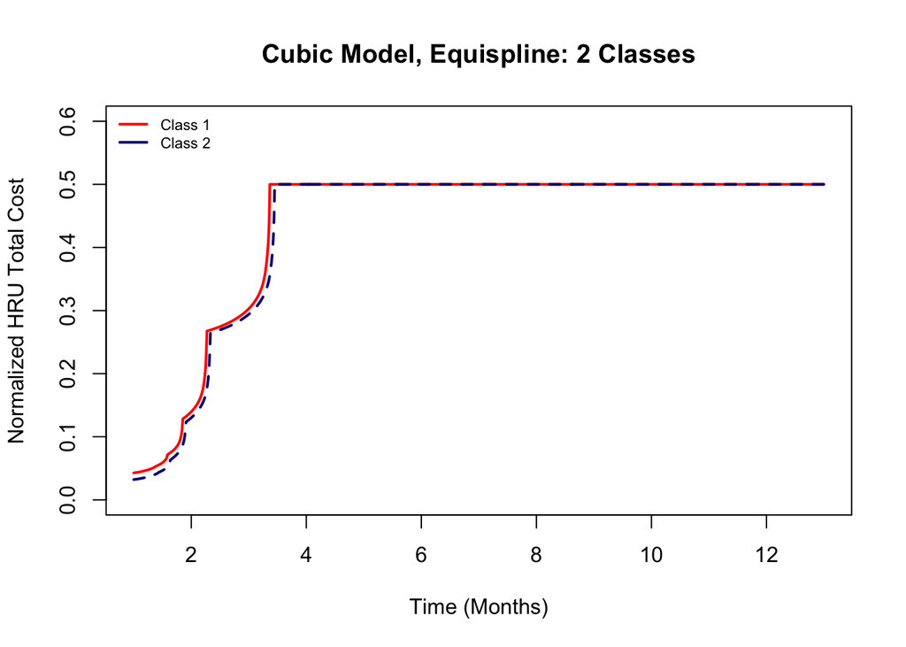

```r
OEP_data<-data.frame(Time= seq(1,13, length=1000))
OEP_pred <- predictY(model17b, OEP_data, var.time ="Time", draws = FALSE)
plot(OEP_pred, col=c("red","navy"), lwd = 2, xlab="Time (Months)", ylab="Normalized HRU Total Cost", legend=NULL, main="Cubic Model, Equispline: 2 Classes",ylim=c(0,.6))
legend(x="topleft",legend=c("Class 1","Class 2"), col=c("red","navy"), lty=1,lwd=2, ncol=1, bty="n", cex = 0.7)
```

Cubic, equi-spline model with 3 classes

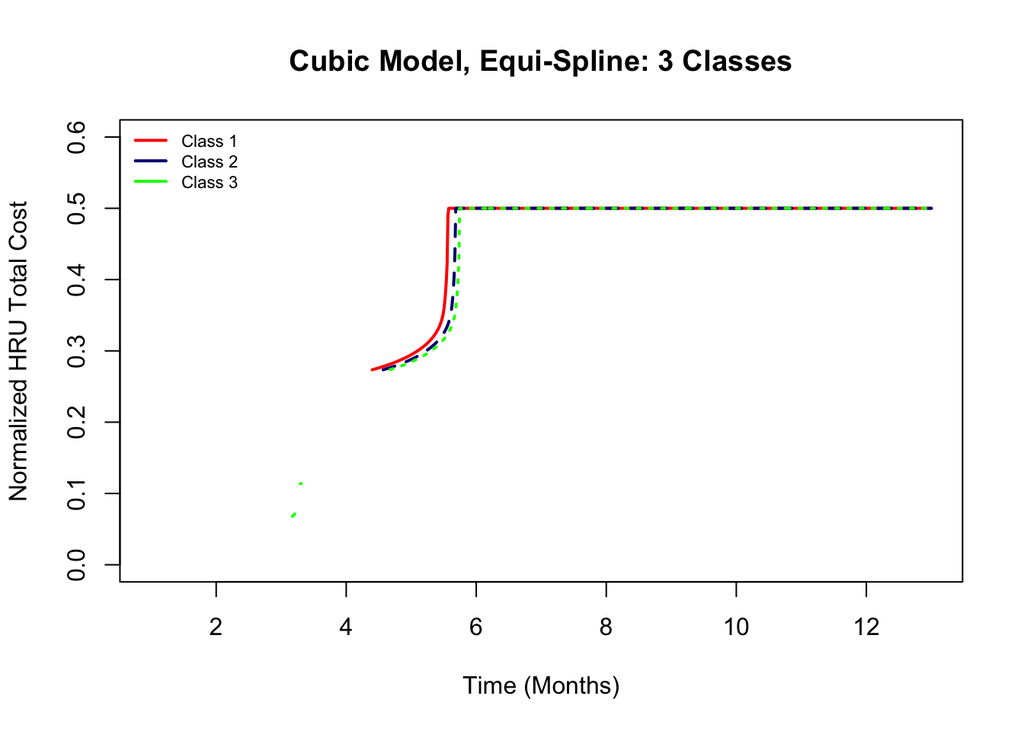

```r
OEP_data<-data.frame(Time= seq(1,13, length=1000))
OEP_pred <- predictY(model17c, OEP_data, var.time ="Time", draws = FALSE)
plot(OEP_pred, col=c("red","navy", "green"), lwd = 2, xlab="Time (Months)", ylab="Normalized HRU Total Cost", legend=NULL, main="Cubic Model, Equi-Spline: 3 Classes",ylim=c(0,.6))
legend(x="topleft",legend=c("Class 1","Class 2", "Class 3"), col=c("red","navy", "green"), lty=1,lwd=2, ncol=1, bty="n", cex = 0.7)
```

Neither of these models fit well

### 4.1.2) Log-transformed data

```r
model19<-lcmm(HRU_log~Time, random=~ Time, subject='ID', ng = 1 , link = 'linear', data = long.data2)
model20<-lcmm(HRU_log~Time, random=~Time, subject='ID', ng = 1 , link = '3-equi-splines', data = long.data2)
model21<-lcmm(HRU_log~Time, random=~Time, subject='ID', ng = 1 , link = '3-quant-splines', data = long.data2)
model22<-lcmm(HRU_log~Time + I(Time^2), random=~ Time + I(Time^2), subject='ID', ng = 1 , link = 'linear', data = long.data2)
model23<-lcmm(HRU_log~Time + I(Time^2), random=~Time + I(Time^2), subject='ID', ng = 1 , link = '3-equi-splines', data = long.data2)
model24<-lcmm(HRU_log~Time + I(Time^2), random=~Time + I(Time^2), subject='ID', ng = 1 , link = '3-quant-splines', data = long.data2)
model25<-lcmm(HRU_log~Time + I(Time^2) + I(Time^3), random=~ Time + I(Time^2) + I(Time^3), subject='ID', ng = 1 , link = 'linear', data = long.data2)
model26<-lcmm(HRU_log~Time + I(Time^2) + I(Time^3), random=~Time + I(Time^2) + I(Time^3), subject='ID', ng = 1 , link = '3-equi-splines', data = long.data2)
model27<-lcmm(HRU_log~Time + I(Time^2) + I(Time^3), random=~Time + I(Time^2) + I(Time^3), subject='ID', ng = 1 , link = '3-quant-splines', data = long.data2)

summarytable(model19, model20, model21, model22, model23, model24, model25, model26, model27, which = c("G", "loglik", "conv", "npm", "AIC", "BIC", "SABIC", "entropy","ICL", "%class"))
```

```
##         G     loglik conv npm      AIC      BIC    SABIC entropy     ICL1
## model19 1 -10410.206    1   6 20832.41 20855.44 20836.40       1 20855.44
## model20 1  -9135.433    1   9 18288.87 18323.41 18294.86       1 18323.41
## model21 1  -9007.248    1   9 18032.50 18067.04 18038.49       1 18067.04
## model22 1 -10380.954    1  10 20781.91 20820.29 20788.56       1 20820.29
## model23 1  -9108.385    1  13 18242.77 18292.66 18251.42       1 18292.66
## model24 1  -8979.697    1  13 17985.39 18035.28 17994.05       1 18035.28
## model25 1 -14492.035    2  15 29014.07 29071.64 29024.05       1 29071.64
## model26 1 -13545.293    2  18 27126.59 27195.67 27138.57       1 27195.67
## model27 1 -12781.769    2  18 25599.54 25668.62 25611.52       1 25668.62
##             ICL2 %class1
## model19 20855.44     100
## model20 18323.41     100
## model21 18067.04     100
## model22 20820.29     100
## model23 18292.66     100
## model24 18035.28     100
## model25 29071.64     100
## model26 27195.67     100
## model27 25668.62     100
```

The best fitting models were quadratic 3-quant spline (model 24), 1st order 3-quant spline (model 21), and quadratic 3-equi-spline (model 23)

Quadratic 3-quant spline models are described below. The best fitting models were 2 class (model 24b) and 3 class models (model 24c).

```r
model24a<-lcmm(HRU_log~Time + I(Time^2), random=~ Time + I(Time^2), subject='ID', ng = 1 , link = '3-quant-splines', data = long.data2)
model24b<-lcmm(HRU_log~Time + I(Time^2), random=~ Time + I(Time^2),  mixture =~ Time + I(Time^2), subject='ID', ng = 2 , link = '3-quant-splines', data = long.data2, B=model24a)
model24c<-lcmm(HRU_log~Time + I(Time^2), random=~ Time + I(Time^2),  mixture =~ Time + I(Time^2), subject='ID', ng = 3 , link = '3-quant-splines', data = long.data2, B=model24a)
model24d<-lcmm(HRU_log~Time + I(Time^2), random=~ Time + I(Time^2),  mixture =~ Time + I(Time^2), subject='ID', ng = 4 , link = '3-quant-splines', data = long.data2, B=model24a)
model24e<-lcmm(HRU_log~Time + I(Time^2), random=~ Time + I(Time^2),  mixture =~ Time + I(Time^2), subject='ID', ng = 5 , link = '3-quant-splines', data = long.data2, B=model24a)
model24f<-lcmm(HRU_log~Time + I(Time^2), random=~ Time + I(Time^2),  mixture =~ Time + I(Time^2), subject='ID', ng = 6 , link = '3-quant-splines', data = long.data2, B=model24a)

summarytable(model24a, model24b, model24c, model24d, model24e, model24f, which = c("G", "loglik", "conv", "npm", "AIC", "BIC", "SABIC", "entropy","ICL", "%class"))
```

```
##          G    loglik conv npm      AIC      BIC    SABIC   entropy     ICL1
## model24a 1 -8979.697    1  13 17985.39 18035.28 17994.05 1.0000000 18035.28
## model24b 2 -8958.943    1  17 17951.89 18017.13 17963.20 0.7270497 18082.02
## model24c 3 -8955.789    1  21 17953.58 18034.17 17967.55 0.6014162 18184.37
## model24d 4 -8949.409    1  25 17948.82 18044.76 17965.46 0.6512106 18210.61
## model24e 5 -8943.846    1  29 17945.69 18056.99 17964.99 0.6646602 18242.11
## model24f 6 -8942.114    1  33 17950.23 18076.87 17972.19 0.6152310 18313.34
##              ICL2    %class1   %class2   %class3   %class4  %class5  %class6
## model24a 18035.28 100.000000
## model24b 18083.96  67.930029 32.069971
## model24c 18194.25  24.489796 33.819242 41.690962
## model24d 18218.68   8.454810 32.944606 18.075802 40.524781
## model24e 18244.01  34.985423  5.539359  9.329446 32.361516 17.78426
## model24f 18324.90   6.413994 32.069971 23.032070  4.956268 18.95044 14.57726
```

1st order 3-quant spline models are described below. The best fitting models was the 2 class model (model 21b)

```r
model21a<-lcmm(HRU_log~Time, random=~ Time, subject='ID', ng = 1 , link = '3-quant-splines', data = long.data2)
model21b<-lcmm(HRU_log~Time, random=~ Time, subject='ID', mixture =~ Time, ng = 2 , link = '3-quant-splines', data = long.data2, B=model21a)
model21c<-lcmm(HRU_log~Time, random=~ Time, subject='ID', mixture =~ Time, ng = 3 , link = '3-quant-splines', data = long.data2, B=model21a)
model21d<-lcmm(HRU_log~Time, random=~ Time, subject='ID', mixture =~ Time, ng = 4 , link = '3-quant-splines', data = long.data2, B=model21a)
model21e<-lcmm(HRU_log~Time, random=~ Time, subject='ID', mixture =~ Time, ng = 5 , link = '3-quant-splines', data = long.data2, B=model21a)
model21f<-lcmm(HRU_log~Time, random=~ Time, subject='ID', mixture =~ Time, ng = 6 , link = '3-quant-splines', data = long.data2, B=model21a)

summarytable(model21a, model21b, model21c, model21d, model21e, model21f, which = c("G", "loglik", "conv", "npm", "AIC", "BIC", "SABIC", "entropy","ICL", "%class"))
```

```
##          G    loglik conv npm      AIC      BIC    SABIC   entropy     ICL1
## model21a 1 -9007.248    1   9 18032.50 18067.04 18038.49 1.0000000 18067.04
## model21b 2 -8987.004    1  12 17998.01 18044.06 18005.99 0.7202934 18110.56
## model21c 3 -8985.890    1  15 18001.78 18059.35 18011.76 0.5791660 18217.93
## model21d 4 -8981.370    1  18 17998.74 18067.82 18010.72 0.6441937 18237.00
## model21e 5 -8980.573    1  21 18003.15 18083.74 18017.12 0.5872980 18311.56
## model21f 6 -8979.127    1  24 18006.25 18098.36 18022.23 0.6373582 18321.23
##              ICL2    %class1   %class2  %class3  %class4   %class5  %class6
## model21a 18067.04 100.000000
## model21b 18112.82  69.096210 30.903790
## model21c 18226.98  39.358601 37.026239 23.61516
## model21d 18244.56   8.746356 36.151603 18.36735 36.73469
## model21e 18332.41  24.489796 34.402332 13.41108 17.20117 10.495627
## model21f 18327.67  23.323615  8.163265 35.56851 13.11953  6.122449 13.70262
```

Quadratic 3-equi spline models are described below. The best fitting model was the 2 class model (model 23b)

```r
model23a<-lcmm(HRU_log~Time + I(Time^2), random=~ Time + I(Time^2), subject='ID', ng = 1 , link = '3-equi-splines', data = long.data2)
model23b<-lcmm(HRU_log~Time + I(Time^2), random=~ Time + I(Time^2),  mixture =~ Time + I(Time^2), subject='ID', ng = 2 , link = '3-equi-splines', data = long.data2, B=model23a)
model23c<-lcmm(HRU_log~Time + I(Time^2), random=~ Time + I(Time^2),  mixture =~ Time + I(Time^2), subject='ID', ng = 3 , link = '3-equi-splines', data = long.data2, B=model23a)
model23d<-lcmm(HRU_log~Time + I(Time^2), random=~ Time + I(Time^2),  mixture =~ Time + I(Time^2), subject='ID', ng = 4 , link = '3-equi-splines', data = long.data2, B=model23a)
model23e<-lcmm(HRU_log~Time + I(Time^2), random=~ Time + I(Time^2),  mixture =~ Time + I(Time^2), subject='ID', ng = 5 , link = '3-equi-splines', data = long.data2, B=model23a)
model23f<-lcmm(HRU_log~Time + I(Time^2), random=~ Time + I(Time^2),  mixture =~ Time + I(Time^2), subject='ID', ng = 6 , link = '3-equi-splines', data = long.data2, B=model23a)

summarytable(model23a, model23b, model23c, model23d, model23e, model23f, which = c("G", "loglik", "conv", "npm", "AIC", "BIC", "SABIC", "entropy","ICL", "%class"))
```

```
##          G    loglik conv npm      AIC      BIC    SABIC   entropy     ICL1
## model23a 1 -9108.385    1  13 18242.77 18292.66 18251.42 1.0000000 18292.66
## model23b 2 -9088.748    1  17 18211.50 18276.74 18222.81 0.7199142 18343.33
## model23c 3 -9085.522    1  21 18213.04 18293.64 18227.02 0.5996843 18444.48
## model23d 4 -9079.388    1  25 18208.78 18304.72 18225.41 0.6533037 18469.57
## model23e 5 -9076.395    1  29 18210.79 18322.08 18230.09 0.6030255 18541.23
## model23f 6 -9072.610    1  33 18211.22 18337.87 18233.18 0.6105952 18577.18
##              ICL2    %class1  %class2  %class3   %class4  %class5  %class6
## model23a 18292.66 100.000000
## model23b 18345.11  67.930029 32.06997
## model23c 18454.35  24.489796 31.48688 44.02332
## model23d 18477.45   7.871720 31.19534 18.36735 42.565598
## model23e 18554.53   5.247813 31.19534 25.36443 18.950437 19.24198
## model23f 18591.65   6.413994 30.02915 25.07289  4.956268 14.57726 18.95044
```

Here is a comparison of the best fitting models.

```r
summarytable(model24b, model24c, model21b, model23b, which = c("G", "loglik", "conv", "npm", "AIC", "BIC", "SABIC", "entropy","ICL", "%class"))
```

[output not shown]

We then plotted the the trajectories of each model

Quadratic 3-quant spline with 2 classes

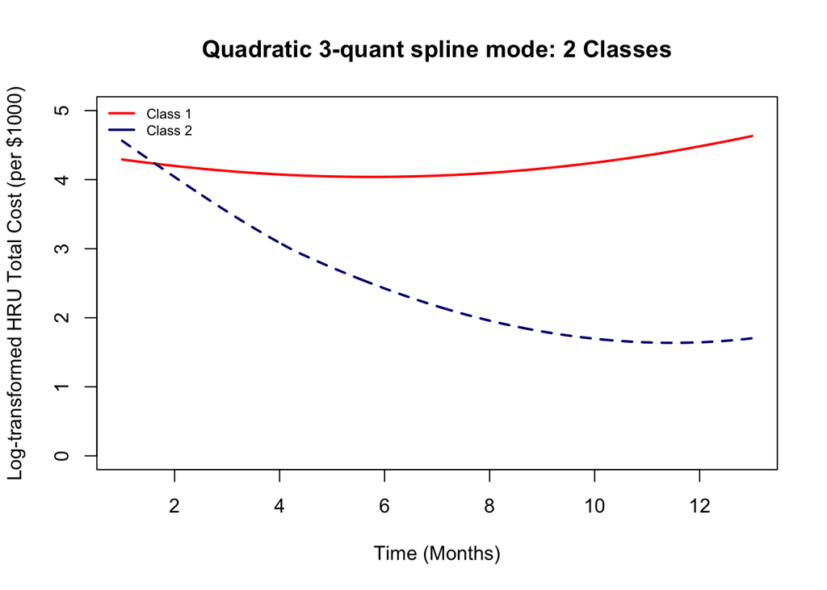

```r
OEP_data<-data.frame(Time= seq(1,13, length=1000))
OEP_pred <- predictY(model24b, OEP_data, var.time ="Time", draws = FALSE)
plot(OEP_pred, col=c("red","navy"), lwd = 2, xlab="Time (Months)", ylab="Log-transformed HRU Total Cost (per $1000)", legend=NULL, main="Quadratic 3-quant spline mode: 2 Classes",ylim=c(0,5))
legend(x="topleft",legend=c("Class 1","Class 2"), col=c("red","navy"), lty=1,lwd=2, ncol=1, bty="n", cex = 0.7)
```

Quadratic 3-quant spline with 3 classes

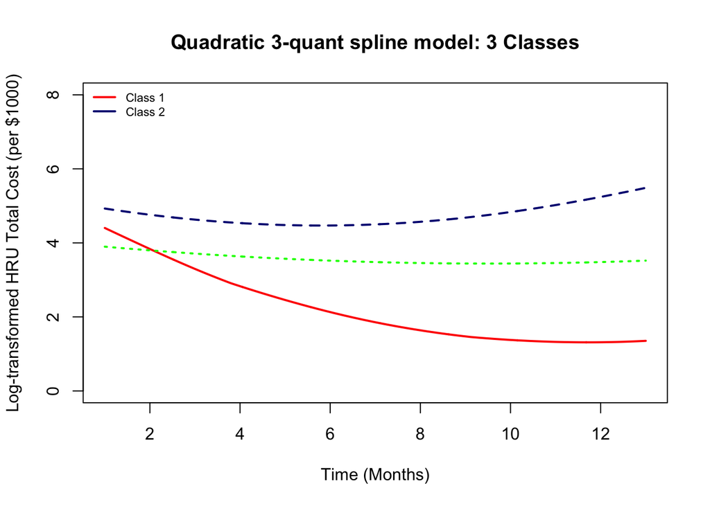

```r
OEP_data<-data.frame(Time= seq(1,13, length=1000))
OEP_pred <- predictY(model24c, OEP_data, var.time ="Time", draws = FALSE)
plot(OEP_pred, col=c("red","navy", "green"), lwd = 2, xlab="Time (Months)", ylab="Log-transformed HRU Total Cost (per $1000)", legend=NULL, main="Quadratic 3-quant spline model: 3 Classes",ylim=c(0,8))
legend(x="topleft",legend=c("Class 1","Class 2"), col=c("red","navy", "green"), lty=1,lwd=2, ncol=1, bty="n", cex = 0.7)
```

1st order 3-quant spline with 2 classes

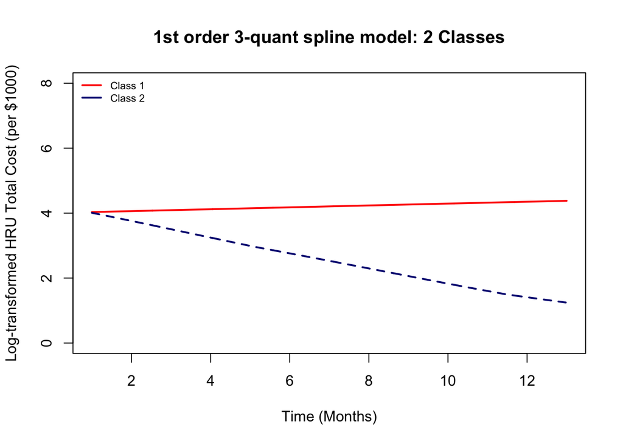

```r
OEP_data<-data.frame(Time= seq(1,13, length=1000))
OEP_pred <- predictY(model21b, OEP_data, var.time ="Time", draws = FALSE)
plot(OEP_pred, col=c("red","navy"), lwd = 2, xlab="Time (Months)", ylab="Log-transformed HRU Total Cost (per $1000)", legend=NULL, main="1st order 3-quant spline model: 2 Classes",ylim=c(0,8))
legend(x="topleft",legend=c("Class 1","Class 2"), col=c("red","navy"), lty=1,lwd=2, ncol=1, bty="n", cex = 0.7)
```

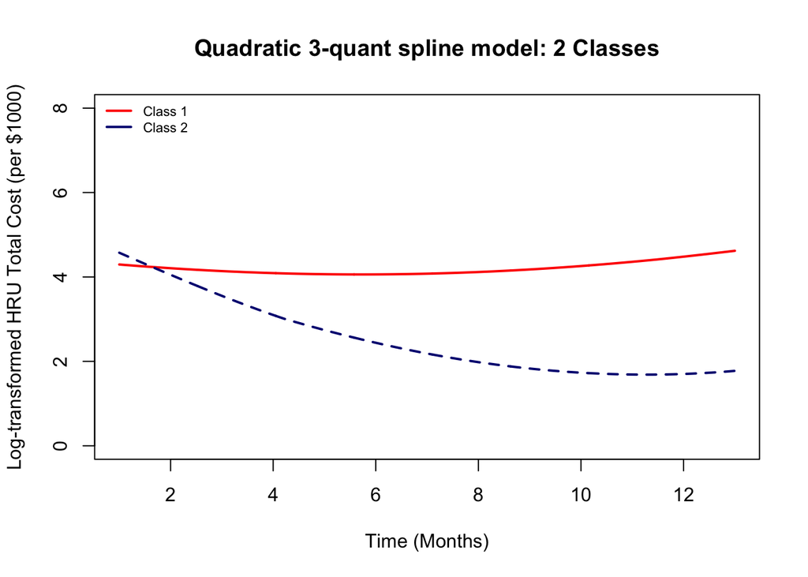

```r
OEP_data<-data.frame(Time= seq(1,13, length=1000))
OEP_pred <- predictY(model23b, OEP_data, var.time ="Time", draws = FALSE)
plot(OEP_pred, col=c("red","navy"), lwd = 2, xlab="Time (Months)", ylab="Log-transformed HRU Total Cost (per $1000)", legend=NULL, main="Quadratic 3-quant spline model: 2 Classes",ylim=c(0,8))
legend(x="topleft",legend=c("Class 1","Class 2"), col=c("red","navy"), lty=1,lwd=2, ncol=1, bty="n", cex = 0.7)
```

### 4.1.3) Final Model

Based on these data, the most simple and easily interpretable model is model21b.

```r
summary(model21b)
```

```
## General latent class mixed model
##      fitted by maximum likelihood method
##
## lcmm(fixed = HRU_log ~ Time, mixture = ~Time, random = ~Time,
##     subject = "ID", ng = 2, link = "3-quant-splines", data = long.data2)
##
## Statistical Model:
##      Dataset: long.data2
##      Number of subjects: 343
##      Number of observations: 4445
##      Number of observations deleted: 14
##      Number of latent classes: 2
##      Number of parameters: 12
##      Link function: Quadratic I-splines with nodes
## 0 4.837626 10.827
##
## Iteration process:
##      Convergence criteria satisfied
##      Number of iterations:  25
##      Convergence criteria: parameters= 4.7e-09
##                          : likelihood= 3.7e-06
##                          : second derivatives= 1.5e-06
##
## Goodness-of-fit statistics:
##      maximum log-likelihood: -8987
##      AIC: 17998.01
##      BIC: 18044.06
##
##
## Maximum Likelihood Estimates:
##
## Fixed effects in the class-membership model:
## (the class of reference is the last class)
##
##                      coef      Se    Wald p-value
## intercept class1  0.72564 0.16766   4.328 0.00002
##
## Fixed effects in the longitudinal model:
##
##                                      coef      Se    Wald p-value
## intercept class1 (not estimated)        0
## intercept class2                  0.12403 0.11230   1.104 0.26940
## Time class1                       0.01409 0.00600   2.348 0.01888
## Time class2                      -0.12154 0.00982 -12.373 0.00000
##
##
## Variance-covariance matrix of the random-effects:
##           intercept    Time
## intercept   0.29585
## Time       -0.01080 0.00039
##
## Residual standard error (not estimated) = 1
##
## Parameters of the link function:
##
##                coef      Se    Wald p-value
## I-splines1 -1.63597 0.05888 -27.785 0.00000
## I-splines2  1.00704 0.01116  90.243 0.00000
## I-splines3 -0.00002 0.01518  -0.001 0.99905
## I-splines4  2.01541 0.01644 122.559 0.00000
## I-splines5  0.49109 0.13507   3.636 0.00028
```

```r
postprob(model21b)
```

```
##
## Posterior classification:
##   class1 class2
## N  237.0  106.0
## %   69.1   30.9
##
## Posterior classification table:
##      --> mean of posterior probabilities in each class
##         prob1  prob2
## class1 0.9271 0.0729
## class2 0.1075 0.8925
##
## Posterior probabilities above a threshold (%):
##          class1 class2
## prob>0.7  90.30  83.02
## prob>0.8  84.81  78.30
## prob>0.9  78.48  67.92
##
```

Graph of model 21b

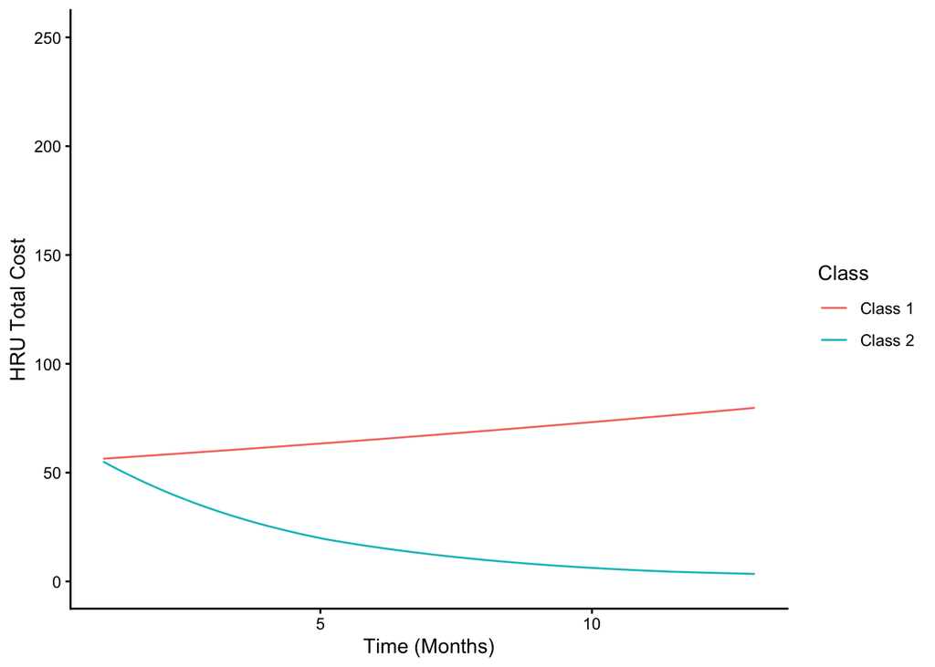

```r
OEP_data<-data.frame(Time= seq(1,13, length=1000))
OEP_pred <- predictY(model21b, OEP_data, var.time ="Time", draws = FALSE)
Time<-OEP_pred$times
Classes<-as.data.frame(OEP_pred$pred)
OEP_data_frame<-cbind(Time, Classes)
OEP_data_frame$class1_untrans<-exp(OEP_data_frame$Ypred_class1)
OEP_data_frame$class2_untrans<-exp(OEP_data_frame$Ypred_class2)

Class1_frame<-OEP_data_frame[c(1,4)]
Class2_frame<-OEP_data_frame[c(1,5)]
Class1_frame$Class<- "Class 1"
Class2_frame$Class<- "Class 2"

Class1_frame<-rename(Class1_frame,c("HRU"="class1_untrans"))
Class2_frame<-rename(Class2_frame,c("HRU"="class2_untrans"))

graph_data<-rbind(Class1_frame, Class2_frame)

ggplot(graph_data, aes(x=Time, y=HRU, group=Class)) + geom_line(aes(colour=Class)) + theme_classic() + xlab("Time (Months)") + ylab("HRU Total Cost") + ylim(0,250)
```

### 4.1.4) Class descriptions

Create data frame with classes

```r
model21b.frame<-model21b$pprob

baseline.data.3<-merge(model21b.frame, falls_plus_HRU_3, by="ID")

baseline.data.4 <- rename(baseline.data.3, "Falls_number" = "Total Falls", "Final_Weight" = "Final Weight", "Final_Height"="Final Height", "WHR"="Waist to Hip Ratio","FCI"="FCI Total",
                          "IADL"="Total IADL", "TrailsBA"="Trail Difference","TUG"="Mean TUG", "GaitSpeed"="Gait Speed", "SPPB"="NIA Total Score")

baseline.data.4$Gender[baseline.data.4$Gender==1]<-"Female"
baseline.data.4$Gender[baseline.data.4$Gender==2]<-"Male"

baseline.data.4$BMI<-baseline.data.4$Final_Weight/((baseline.data.4$Final_Height/100)^2)
```

Describe participants

```r
baseline.vars.2<-dput(names(baseline.data.4[c(11,5,15,14,36,18,19,21,10,31,32,34,22,23,34,35)]))
```

```
## c("Age", "Gender", "Education", "WHR", "BMI", "GDS", "FCI", "IADL",
## "Falls_number", "TUG", "GaitSpeed", "Stroop3_2", "MMSE", "MoCA",
## "Stroop3_2.1", "DSFB")
```

```r
Table1_full<-CreateTableOne(vars=baseline.vars.2, strata="class", data=baseline.data.4)
print(Table1_full,contDigits=2,missing=TRUE,quote=TRUE)
```

```
##                                                      "Stratified by class"
##  ""                                                   "1"
##   "n"                                                 "  237"
##   "Age (mean (SD))"                                   "81.35 (6.03)"
##   "Gender = Male (%)"                                 "   82 (34.6) "
##   "Education (%)"                                     "   "
##   "   Grades 9-13, without certificate or diploma"    "   19 (10.5) "
##   "   High school certificate or diploma"             "   31 (17.1) "
##   "   Less than grade 9"                              "    7 ( 3.9) "
##   "   Some university without certificate or diploma" "   20 (11.0) "
##   "   Trades or professional certificate or diploma"  "   28 (15.5) "
##   "   University certificate or diploma"              "    7 ( 3.9) "
##   "   University degree"                              "   69 (38.1) "
##   "WHR (mean (SD))"                                   " 0.91 (0.10)"
##   "BMI (mean (SD))"                                   "27.26 (5.40)"
##   "GDS (mean (SD))"                                   " 2.81 (2.42)"
##   "FCI (mean (SD))"                                   " 3.75 (2.06)"
##   "IADL (mean (SD))"                                  " 7.31 (1.15)"
##   "Falls_number (mean (SD))"                          " 2.06 (3.36)"
##   "TUG (mean (SD))"                                   "16.62 (6.91)"
##   "GaitSpeed (mean (SD))"                             " 0.79 (0.34)"
##   "Stroop3_2 (mean (SD))"                             "76.35 (41.91)"
##   "MMSE (mean (SD))"                                  "27.79 (1.61)"
##   "MoCA (mean (SD))"                                  "23.19 (3.35)"
##   "DSFB (mean (SD))"                                  " 3.61 (1.98)"
##                                                      "Stratified by class"
##  ""                                                   "2"             "p"
##   "n"                                                 "  106"         ""
##   "Age (mean (SD))"                                   "82.08 (6.21)"  " 0.302"
##   "Gender = Male (%)"                                 "   33 (31.1) " " 0.614"
##   "Education (%)"                                     "   "           " 0.101"
##   "   Grades 9-13, without certificate or diploma"    "    3 ( 3.2) " ""
##   "   High school certificate or diploma"             "   16 (17.2) " ""
##   "   Less than grade 9"                              "    1 ( 1.1) " ""
##   "   Some university without certificate or diploma" "    6 ( 6.5) " ""
##   "   Trades or professional certificate or diploma"  "   13 (14.0) " ""
##   "   University certificate or diploma"              "    6 ( 6.5) " ""
##   "   University degree"                              "   48 (51.6) " ""
##   "WHR (mean (SD))"                                   " 0.89 (0.11)"  " 0.121"
##   "BMI (mean (SD))"                                   "27.15 (8.28)"  " 0.883"
```

[output cut: 20 more lines]

```
##   "   Trades or professional certificate or diploma"  ""     "    "
##   "   University certificate or diploma"              ""     "    "
##   "   University degree"                              ""     "    "
##   "WHR (mean (SD))"                                   ""     "14.9"
##   "BMI (mean (SD))"                                   ""     " 0.6"
##   "GDS (mean (SD))"                                   ""     " 0.0"
##   "FCI (mean (SD))"                                   ""     " 0.6"
##   "IADL (mean (SD))"                                  ""     " 0.3"
##   "Falls_number (mean (SD))"                          ""     " 0.0"
##   "TUG (mean (SD))"                                   ""     " 0.3"
##   "GaitSpeed (mean (SD))"                             ""     " 0.0"
##   "Stroop3_2 (mean (SD))"                             ""     " 1.5"
##   "MMSE (mean (SD))"                                  ""     " 0.0"
##   "MoCA (mean (SD))"                                  ""     " 0.0"
##   "DSFB (mean (SD))"                                  ""     " 2.0"
```

# 5) Figure 1 REVISED

Exclude Class 1 and Class 3 from the graph

```r
OEP_pred <- predictY(model3d, OEP_data, var.time ="Time", draws = FALSE)
OEP_pred_filtered <- OEP_pred$pred[, c("Ypred_class2", "Ypred_class4")]
tiff("Figure 1 REVISED.tiff", width=800, height=400)
plot(OEP_pred_filtered[,1], type="l", col="navy", lwd=2, xlab="Time (Months)", ylab="HRU Total Cost (per $1000)",
     ylim=c(0,5))
lines(OEP_pred_filtered[,2], col="purple", lwd=2, lty=2)
legend(x="topleft", legend=c("Class 2", "Class 4"), col=c("navy", "purple"), lty=1, lwd=2, ncol=1, bty="n", cex=0.7)
dev.off()
```

# 6) Figure 2 REVISED

Exclude Class 1 and Class 3

```r
Sex_mod_data<-data.frame(Time= seq(1,13, length=1000), Sex=rep(c("Male","Female")))
Sex_mod_pred <- predictY(sex.model.moderation, Sex_mod_data, var.time ="Time", draws = FALSE)

Time<-Age_mod_pred$times
Sex <- rep(c('Male', 'Female'), length.out = 1000)
Classes<-as.data.frame(Sex_mod_pred$pred)
Sex_mod_data_frame<-cbind(Time, Sex, Classes)

Class2_frame<-Sex_mod_data_frame[c(1,2,4)]
Class4_frame<-Sex_mod_data_frame[c(1,2,6)]
Class2_frame$Class<- "Class 2"
Class4_frame$Class<- "Class 4"
Class2_frame <- rename(Class2_frame, "Predicted" = "Ypred_class2")
Class4_frame <- rename(Class4_frame, "Predicted" = "Ypred_class4")

graph_data<-rbind(Class2_frame, Class4_frame)

figure2C<-ggplot(graph_data, aes(x=Time, y=Predicted, color=Class, linetype=Sex)) + geom_smooth(aes(colour=Class, linetype=Sex)) + theme_classic() + xlab("Time (Months)") + ylab("HRU Total Cost (per $1000 CAD") + ylim(0,5)

ggsave("Figure 2 REVISED.tiff",figure2C, width = 6, height = 6, dpi = 300)
```